# Forest Cover Predictions Using Decision Tree, Random Forest, and SVM Models

Stephanie Gillihan | CSPB 4622 Machine Learning | Fall 2026

### Background and Overview

This project compares three supervised machine learning models (Decision Tree, Random Forest, and Support Vector Machine) to predict forest cover type using geographic and environmental data from the UCI Forest Covertype dataset. The main goal is to compare how well the models perform and to understand the strengths and weaknesses of each approach. Along the way, parameter tuning and scalability of the models are also explored.

The project begins with exploratory data analysis and basic data preparation. Next, each model is tested with a small set of hyperparameter values to see how those settings affect performance and to choose reasonable starting values. The models are then evaluated across repeated stratified random samples so their accuracy, stability, and consistency can be compared in a robust manner. Scalability analysis is conducted to detrmined the feasibility of traning on the entire data set. Based on those results, the models are fine-tuned and run on a final sample. The final section compares overall performance, training time, interpretability, and the practical tradeoffs between the three models.

Please note, Claude code was used to code each section. Project dataset choice, model choice, project design, and all discussion/commentary were composed by Stephanie Gillihan.

Link to personal repository: https://github.com/sgillihan/CSPB4622_Project1_Forest_Cover.git

Link to classroom specific repository: https://github.com/cu-cspb-4622-fall-2026/sgillihan_forest_cover.git

#### Citations

Blackard, J. (1998). Covertype [Dataset]. UCI Machine Learning Repository. https://doi.org/10.24432/C50K5N.

GeeksforGeeks. (2026, August 12). Decision tree in machine learning. https://www.geeksforgeeks.org/machine-learning/decision-tree-introduction-example/

GeeksforGeeks. (2026, May 2). Random forest algorithm in machine learning. https://www.geeksforgeeks.org/machine-learning/random-forest-algorithm-in-machine-learning/

GeeksforGeeks. (2026, May 2). Support vector machine (SVM) algorithm. https://www.geeksforgeeks.org/machine-learning/support-vector-machine-algorithm/

1. Section I: Data Set-up, Exploratory Data Analysis, and Project Design
2. Section II: Preliminary Models and Hyperparameter Observations
3. Section III: Repeated Model Evaluation on Stratified Random Samples
4. Section IV: Scalability
5. Section V: Final Model Training and Comparison

## Section I: Data Set-up, Exploratory Data Analysis, and Project Design

This section imports all required libraries for the project, processes the zipped data, and sets up functions for selecting stratified random samples. This section will also include Exploratory Data Analysis (EDA). EDA summarizes the data in tabular or graphical form in order to develop better understanding of features, value ranges, data formats, etc. Finally, this section lays out and summarizes the project design.

Import libraries:

```python
# Import all necessary libraries

# general
import time               # used to time how long each model takes to train and predict
import zipfile            # the raw data is zipped, so this reads it without extracting it first
from pathlib import Path  # builds file paths that work on Windows, Mac, and Linux

# Data/Plotting
import numpy as np                 # numeric arrays
import pandas as pd                # DataFrames for holding data and results
import matplotlib.pyplot as plt    # base plotting library
import seaborn as sns              # additional plots

# scikit-learn
from sklearn.model_selection import train_test_split, StratifiedKFold, GridSearchCV # cross-validation and hyperparameter tuning
from sklearn.dummy import DummyClassifier           # majority-class baseline
from sklearn.tree import DecisionTreeClassifier     # Decision Tree (also the simple baseline model)
from sklearn.ensemble import RandomForestClassifier # Random Forest
from sklearn.svm import SVC                         # Support Vector Machine
from sklearn.preprocessing import StandardScaler    # SVM needs features on the same scale
from sklearn.pipeline import Pipeline               # keeps scaling and the model together
from sklearn.metrics import (                       # evaluation metrics
    accuracy_score,
    precision_recall_fscore_support,
    f1_score,
    classification_report,
    confusion_matrix,
    ConfusionMatrixDisplay,
)
from sklearn.feature_selection import mutual_info_classif   # feature selection
from sklearn.inspection import permutation_importance       # permutation importance

# One fixed random seed is used as the starting point everywhere so that the results can be reproduced when the notebook is rerun
RANDOM_STATE = 42

sns.set_theme(style="whitegrid")         # consistent look for every plot
pd.set_option("display.max_columns", 60) # show all 55 columns when printing the DataFrame
```

### IA: Setup and Data Loading

The raw data file has no header row, so column names must be manually specified using the covtype.info file that accompanies the main dataset. The first 10 columns are continuous numeric features, the next 44 columns are categorical features, and the final columns is the target variable (Cover_Type). The categorical features are handled using one hot encoding, which is a common method of transforming categorical features into numeric features that machine learning models can use.

```python
# Define 10 continuous quantitative features:
continuous_cols = [
    "Elevation",
    "Aspect",
    "Slope",
    "Horizontal_Distance_To_Hydrology",
    "Vertical_Distance_To_Hydrology",
    "Horizontal_Distance_To_Roadways",
    "Hillshade_9am",
    "Hillshade_Noon",
    "Hillshade_3pm",
    "Horizontal_Distance_To_Fire_Points",
]

# 4 one-hot (0/1) columns for the wilderness areas and 40 for the soil types
wilderness_cols = [f"Wilderness_Area{i}" for i in range(1, 5)]
soil_cols = [f"Soil_Type{i}" for i in range(1, 41)]

# The column the models are trying to predict
target_col = "Cover_Type"

# Every predictor column (54 total), followed by the full list of 55 columns
feature_cols = continuous_cols + wilderness_cols + soil_cols
col_names = feature_cols + [target_col]

# Readable names for the integer class labels (from covtype.info)
# These are only used for plots and tables. The models still train on numeric values 1-7
cover_type_names = {
    1: "Spruce/Fir",
    2: "Lodgepole Pine",
    3: "Ponderosa Pine",
    4: "Cottonwood/Willow",
    5: "Aspen",
    6: "Douglas-fir",
    7: "Krummholz",
}
cover_type_order = list(cover_type_names.values())  # keeps plots in the same 1-7 order

wilderness_names = {
    1: "Rawah",
    2: "Neota",
    3: "Comanche Peak",
    4: "Cache la Poudre",
}

# Load the data straight from the zip file
# covertype.zip contains a gzipped CSV (covtype.data.gz)
# Opening it this way avoids keeping an extracted 70+ MB copy of the data
data_path = Path("data") / "covertype.zip"

with zipfile.ZipFile(data_path) as zf:
    with zf.open("covtype.data.gz") as gz_file:
        # Every value in this dataset is a whole number, and none are larger
        # than about 7,200, so int32 is big enough while still being efficient
        df = pd.read_csv(
            gz_file,
            header=None,
            names=col_names,
            compression="gzip",
            dtype=np.int32,
        )

print(f"Loaded {df.shape[0]:,} rows and {df.shape[1]} columns")
print(f"Memory used: {df.memory_usage(deep=True).sum() / 1e6:.1f} MB")
```

```
Loaded 581,012 rows and 55 columns
Memory used: 127.8 MB
```

#### Stratified Random Samples

Below, some helper functions are defined to support stratified random sampling. Stratified random sampling is a design choice made based on previous experience working with large datasets. Using sampling ensures that model train and predict times are kept reasonable for student level computing resources. Stratified samples ensure that the sub samples used for repeated training iterations keep the same class proportions as the full dataset, and using random sampling remains best practice in the data science field.

```python
# Helper functions for stratified sampling

def get_stratified_sample(data, n_samples, random_state=RANDOM_STATE):
    """Return a stratified random sample of n_samples rows from data.

    Parameters
    ----------
    data : DataFrame
        The full dataset (must contain the target_col column).
    n_samples : int
        How many rows to keep in the sample.
    random_state : int
        Seed so the same sample can be drawn again later.
    """
    # If the requested size is the whole dataset (or more), there is nothing to sample, so just return a copy of all the rows
    if n_samples >= len(data):
        return data.copy()

    # Train_test_split is normally used for train/test splits, but in this case it can be used to draw a stratified sample
    # Only the first piece (the training sample) is kept, the rest is thrown away
    sample, _ = train_test_split(
        data,
        train_size=n_samples,
        stratify=data[target_col],
        random_state=random_state,
    )
    return sample

# Split a stratified sample into stratified training and test sets
def split_features_target(sample, test_size=0.25, random_state=RANDOM_STATE):
    """Split a stratified sample into stratified training and test sets.

    Returns X_train, X_test, y_train, y_test in the same order as
    sklearn's train_test_split.
    """
    X = sample[feature_cols]        # the 54 predictor columns
    y = sample[target_col]          # the cover type labels (1-7)

    # Stratifying again here keeps the class proportions the same in both the training set and the test set.
    return train_test_split(
        X, y,
        test_size=test_size,
        stratify=y,
        random_state=random_state,
    )


# Sanity check-  compare the class proportions in a 10,000 row sample with the proportions in the full dataset
check_sample = get_stratified_sample(df, 10_000)
proportion_check = pd.DataFrame({
    "Full dataset": df[target_col].value_counts(normalize=True),
    "10k sample": check_sample[target_col].value_counts(normalize=True),
}).sort_index().rename(index=cover_type_names)
proportion_check.round(4)
```

| Cover_Type | Full dataset | 10k sample |
| --- | --- | --- |
| Spruce/Fir | 0.3646 | 0.3646 |
| Lodgepole Pine | 0.4876 | 0.4876 |
| Ponderosa Pine | 0.0615 | 0.0615 |
| Cottonwood/Willow | 0.0047 | 0.0047 |
| Aspen | 0.0163 | 0.0164 |
| Douglas-fir | 0.0299 | 0.0299 |
| Krummholz | 0.0353 | 0.0353 |

### IB: Data Description and EDA

The Forest Covertype dataset contains 581,012 observations and 54 predictor features. Ten features are continuous environmental or geographic measurements, including elevation, slope, aspect, hydrology distances, roadway distance, fire-point distance, and hillshade measurements. The remaining 44 predictors are binary indicator variables representing four wilderness areas and 40 soil types. The target variable, Cover_Type, identifies one of seven forest cover classes. All values in the original dataset are stored as integers, and the wilderness area and soil type variables are already one-hot encoded.

```python
# EDA
# head() shows the first few rows of the dataframe so the format of each column is visible.
display(df.head())

# describe() gives the count, mean, std dev, min, max, and quartiles
# Only the continuous features are shown here because summary statistics are not very meaningful for binary indicator columns
df[continuous_cols].describe().T.round(2)
```

|  | Elevation | Aspect | Slope | Horizontal_Distance_To_Hydrology | Vertical_Distance_To_Hydrology | Horizontal_Distance_To_Roadways | Hillshade_9am | Hillshade_Noon | Hillshade_3pm | Horizontal_Distance_To_Fire_Points | Wilderness_Area1 | Wilderness_Area2 | Wilderness_Area3 | Wilderness_Area4 | Soil_Type1 | Soil_Type2 | Soil_Type3 | Soil_Type4 | Soil_Type5 | Soil_Type6 | Soil_Type7 | Soil_Type8 | Soil_Type9 | Soil_Type10 | Soil_Type11 | Soil_Type12 | Soil_Type13 | Soil_Type14 | Soil_Type15 | … |
| --- | --- | --- | --- | --- | --- | --- | --- | --- | --- | --- | --- | --- | --- | --- | --- | --- | --- | --- | --- | --- | --- | --- | --- | --- | --- | --- | --- | --- | --- | --- |
| 0 | 2596 | 51 | 3 | 258 | 0 | 510 | 221 | 232 | 148 | 6279 | 1 | 0 | 0 | 0 | 0 | 0 | 0 | 0 | 0 | 0 | 0 | 0 | 0 | 0 | 0 | 0 | 0 | 0 | 0 | … |
| 1 | 2590 | 56 | 2 | 212 | -6 | 390 | 220 | 235 | 151 | 6225 | 1 | 0 | 0 | 0 | 0 | 0 | 0 | 0 | 0 | 0 | 0 | 0 | 0 | 0 | 0 | 0 | 0 | 0 | 0 | … |
| 2 | 2804 | 139 | 9 | 268 | 65 | 3180 | 234 | 238 | 135 | 6121 | 1 | 0 | 0 | 0 | 0 | 0 | 0 | 0 | 0 | 0 | 0 | 0 | 0 | 0 | 0 | 1 | 0 | 0 | 0 | … |
| 3 | 2785 | 155 | 18 | 242 | 118 | 3090 | 238 | 238 | 122 | 6211 | 1 | 0 | 0 | 0 | 0 | 0 | 0 | 0 | 0 | 0 | 0 | 0 | 0 | 0 | 0 | 0 | 0 | 0 | 0 | … |
| 4 | 2595 | 45 | 2 | 153 | -1 | 391 | 220 | 234 | 150 | 6172 | 1 | 0 | 0 | 0 | 0 | 0 | 0 | 0 | 0 | 0 | 0 | 0 | 0 | 0 | 0 | 0 | 0 | 0 | 0 | … |

|  | count | mean | std | min | 25% | 50% | 75% | max |
| --- | --- | --- | --- | --- | --- | --- | --- | --- |
| Elevation | 581012.0 | 2959.37 | 279.98 | 1859.0 | 2809.0 | 2996.0 | 3163.0 | 3858.0 |
| Aspect | 581012.0 | 155.66 | 111.91 | 0.0 | 58.0 | 127.0 | 260.0 | 360.0 |
| Slope | 581012.0 | 14.10 | 7.49 | 0.0 | 9.0 | 13.0 | 18.0 | 66.0 |
| Horizontal_Distance_To_Hydrology | 581012.0 | 269.43 | 212.55 | 0.0 | 108.0 | 218.0 | 384.0 | 1397.0 |
| Vertical_Distance_To_Hydrology | 581012.0 | 46.42 | 58.30 | -173.0 | 7.0 | 30.0 | 69.0 | 601.0 |
| Horizontal_Distance_To_Roadways | 581012.0 | 2350.15 | 1559.25 | 0.0 | 1106.0 | 1997.0 | 3328.0 | 7117.0 |
| Hillshade_9am | 581012.0 | 212.15 | 26.77 | 0.0 | 198.0 | 218.0 | 231.0 | 254.0 |
| Hillshade_Noon | 581012.0 | 223.32 | 19.77 | 0.0 | 213.0 | 226.0 | 237.0 | 254.0 |
| Hillshade_3pm | 581012.0 | 142.53 | 38.27 | 0.0 | 119.0 | 143.0 | 168.0 | 254.0 |
| Horizontal_Distance_To_Fire_Points | 581012.0 | 1980.29 | 1324.20 | 0.0 | 1024.0 | 1710.0 | 2550.0 | 7173.0 |

#### Discussion of Summary Statistics

The summary statistics above show a count of 581,012 observations for each of the continuous features, which matches the total number of rows in the dataset. This indicates that there are no missing values in these features, which is consistent with the dataset documentation provided by UCI. The values also appear to be recorded as whole numbers, and only one continuous feature (Vertical_Distance_To_Hydrology) contains negative values.

The features vary considerably in their ranges. For example, slope ranges from 0 to 66, while horizontal distances to roadways/firepoints can exceed 7000. The difference in scale will be considered when preparing the data for SVM, since features with larger numeric ranges can have a greater influence on distance-based calculations if the data is not standardized first. Additionally, some features have median values significantly different than their means or maximum values far above their upper quartiles, so the distributions will be examined further for possible skew and/or outliers.

#### Plots

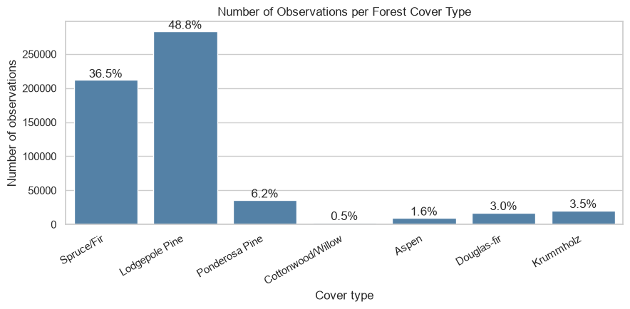

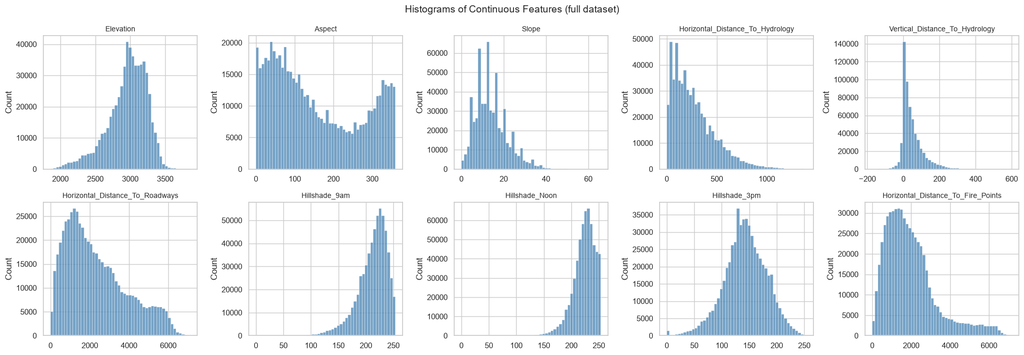

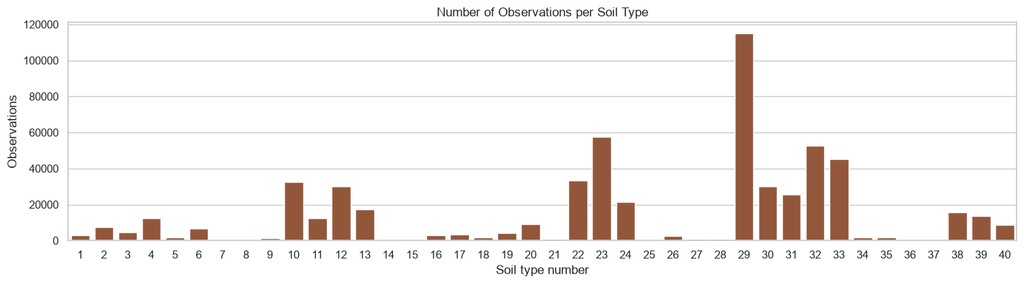

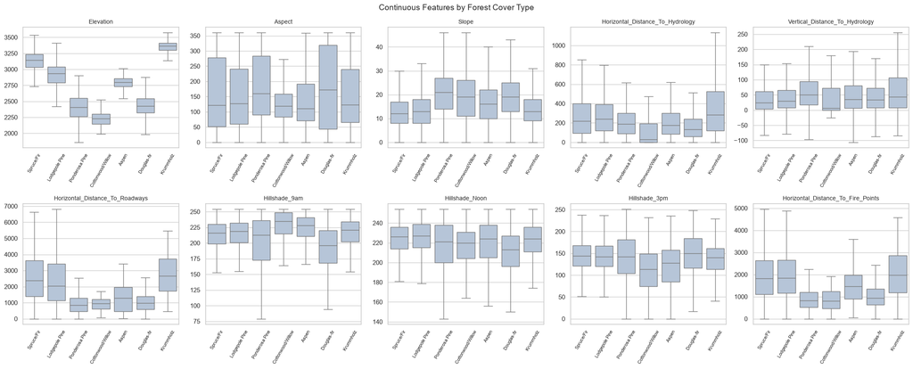

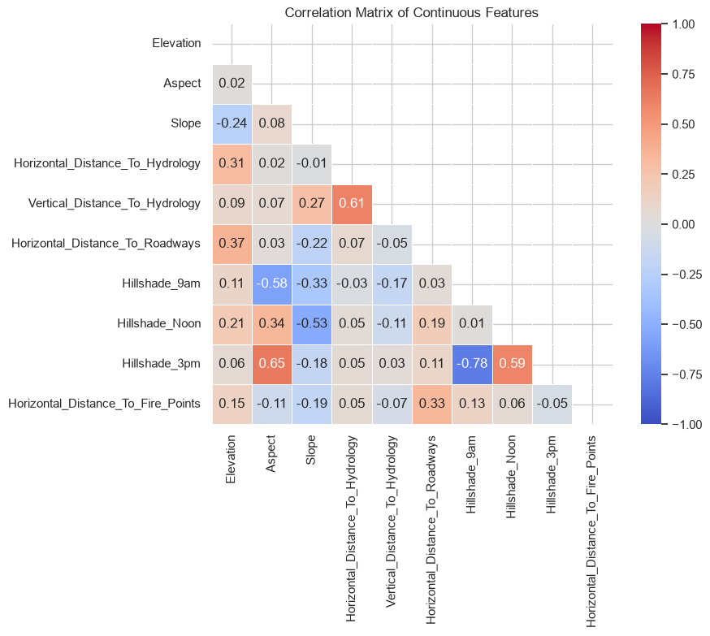

|  |  | Correlation |
| --- | --- | --- |
| Hillshade_3pm | Hillshade_9am | -0.780 |
|  | Aspect | 0.647 |
| Vertical_Distance_To_Hydrology | Horizontal_Distance_To_Hydrology | 0.606 |
| Hillshade_3pm | Hillshade_Noon | 0.594 |
| Hillshade_9am | Aspect | -0.579 |
| Hillshade_Noon | Slope | -0.527 |

```python
# Build a small DataFrame just for the EDA plots
# It wouldn't make sense to plot the one-hot columns directly (44 separate 0/1 columns),
# so this copy of the df uses the original columns and collapses them back into single labeled columns.
#
# This copy is only for EDA plotting purposes. The models will still use the one-hot columns

eda_df = df[continuous_cols].copy()

# argmax finds the position of the "1" in each row. Adding 1 converts the 0-based position into the 1-based area/soil number used in covtype.info
wilderness_num = df[wilderness_cols].to_numpy().argmax(axis=1) + 1
soil_num = df[soil_cols].to_numpy().argmax(axis=1) + 1

eda_df["Wilderness"] = pd.Series(wilderness_num, index=df.index).map(wilderness_names)
eda_df["Soil_Type"] = soil_num
eda_df["Cover"] = pd.Categorical(df[target_col].map(cover_type_names), categories=cover_type_order, ordered=True)

# display the first few rows of the EDA DataFrame so the format of each column is visible
# display(eda_df.head())

#---------

# Plot the number of observations in each cover type class to see if the dataset is balanced or imbalanced
class_counts = eda_df["Cover"].value_counts().reindex(cover_type_order)
class_pct = 100 * class_counts / class_counts.sum()
# Bar chart
fig, ax = plt.subplots(figsize=(9, 4.5))
sns.barplot(x=class_counts.index, y=class_counts.values, color="steelblue", ax=ax)
# Label each bar with its percentage so the imbalance is easy to read
for i, pct in enumerate(class_pct):
    ax.text(i, class_counts.iloc[i], f"{pct:.1f}%", ha="center", va="bottom")

ax.set_title("Number of Observations per Forest Cover Type")
ax.set_xlabel("Cover type")
ax.set_ylabel("Number of observations")
plt.xticks(rotation=30, ha="right")
plt.tight_layout()
plt.show()

#---------

# Plot histograms of the 10 continuous features to see their distributions

fig, axes = plt.subplots(2, 5, figsize=(20, 7))

# axes is a 2x5 grid; flatten() turns it into a simple list of 10 plots
for ax, col in zip(axes.flatten(), continuous_cols):
    sns.histplot(eda_df[col], bins=50, ax=ax, color="steelblue")
    ax.set_title(col, fontsize=10)
    ax.set_xlabel("")

fig.suptitle("Histograms of Continuous Features (full dataset)", fontsize=14)
plt.tight_layout()
plt.show()

# Skew puts a number on what the histograms show
# Generally, skew<.5 is fairly symmetric, skew>1 is strongly skewed
eda_df[continuous_cols].skew().round(2).to_frame("Skewness")

#-----------

# Plot how common each soil type is overall (bar chart)
soil_freq = eda_df["Soil_Type"].value_counts().sort_index()

fig, ax = plt.subplots(figsize=(14, 4))
sns.barplot(x=soil_freq.index, y=soil_freq.values, color="sienna", ax=ax)
ax.set_title("Number of Observations per Soil Type")
ax.set_xlabel("Soil type number")
ax.set_ylabel("Observations")
plt.tight_layout()
plt.show()

#----------

# Display box plots for each continuous feature broken down by cover type
# Boxes at very different heights for different classes is often indicative of a useful feature for prediction

fig, axes = plt.subplots(2, 5, figsize=(22, 9))

for ax, col in zip(axes.flatten(), continuous_cols):
    # showfliers=False hides the individual outlier dots. There are too many of them and they make the boxes hard to read
    sns.boxplot(data=eda_df, x="Cover", y=col, ax=ax, showfliers=False, color="lightsteelblue")
    ax.set_title(col, fontsize=10)
    ax.set_xlabel("")
    ax.set_ylabel("")
    ax.tick_params(axis="x", rotation=60, labelsize=8)

fig.suptitle("Continuous Features by Forest Cover Type", fontsize=14)
plt.tight_layout()
plt.show()

#---------

# A correlation matrix shows which features carry similar information
# Pearson correlation values near +1 or -1 mean two features move together closely, and values near 0 mean little linear relationship
# Highly correlated features are not a problem for tree models, but they are worth noting for interpreting feature importance later

corr = eda_df[continuous_cols].corr()

# Only show the lower triangle, since the upper half is a mirror image
mask = np.triu(np.ones_like(corr, dtype=bool))

fig, ax = plt.subplots(figsize=(10, 8))
sns.heatmap(corr, mask=mask, annot=True, fmt=".2f", cmap="coolwarm", vmin=-1, vmax=1, square=True, linewidths=0.5, ax=ax)
ax.set_title("Correlation Matrix of Continuous Features")
plt.tight_layout()
plt.show()

#----------

# List the most strongly correlated pairs so they are easy to reference in the discussion
# stack() turns the matrix into a list of (feature A, feature B) pairs
pairs = corr.where(~mask).stack().rename("Correlation")
pairs.reindex(pairs.abs().sort_values(ascending=False).index).head(6).round(3).to_frame()
```

#### Discussion of EDA plots

Some important observations can be made based on the EDA plots above. First, the target variable itself is unbalanced, with 2 of the 7 cover types accounting for ~85% of all observations. The unbalanced data may make it difficult for the models to correctly predict the 5 less common cover types. This reinforces the premise that stratified sampling will be critical to preserving the class proportions.

When examining the 10 continuous features, many of the distance based features exhibit a noticeable skew. Elevation and Hillshade 3pm seem to have the most symmetric distributions. As previously discussed in the summary, the value ranges will need to be addressed when prepping the data for SVM. Soil types are also unevenly distributed, with observations concentrated among about a dozen soil types.

The box plots of continuous features broken down by cover type are useful for predictive purposes. Boxes at very different heights for different classes is often indicative of a useful feature for prediction, while many overlapping boxes indicates the feature may be less useful. Based on this theory, it is reasonable to predict that elevation will be found to be the strongest predictor of cover type. Other features show more overlap but may still be useful when considered together with additional environmental variables.

The correlation matrix shows which features carry similar information and are therefore highly correlated. Pearson correlation values near 1 or -1 mean two features move together closely, and values near 0 mean there is little linear relationship. Most features have relatively weak correlations, although there are stronger relationships among some of the hillshade variables and between horizontal and vertical distance to hydrology. Correlated features do not necessarily need to be removed for Decision Tree or Random Forest models, but they should be considered when interpreting feature importance because correlated variables may compete for importance within a model.

### IC: Special Considerations

To ensure consistency of metrics across models, one evaluation function will be written and run on every model. The metrics recorded will be as follows:

- Train and test accuracy: the gap between them is a sign of overfitting
- Macro precision, recall, and F1: "macro" means the score is computed for each class separately and then averaged, so every cover type counts equally no matter how rare it is.
- Fit and predict time: needed for the scalability comparison

Decision Trees and Random Forests split on one feature at a time, so the units of a feature do not matter to them. SVM is different, since it measures distances between points. In an SVM model, a feature measured in thousands (like distance to roadways) would overpower a feature measured from 0 to 1 (like a soil type indicator). Comparing the ranges shows how large this difference is across features.

### ID: Project Design

Below is a summary of the project design for Sections II-V.

Section II: Preliminary Parameter Exploration

- The purpose of Section II is to demonstrate how important parameters affect model behavior and to select reasonable starting values for later testing.
- A medium-sized stratified sample will be used to perform basic parameter experiments for each model.
- Decision Tree parameter tuning experiments will focus on parameters that control tree complexity
- Random Forest parameter tuning experiments will examine the number and depth of trees
- SVM parameter tuning experiments will compare linear and RBF kernels and selected values of C and gamma.

Section III: Repeated Model Evaluation and Parameter Tuning

- Using the starting parameters selected in Section II, all three models will be evaluated across multiple stratified random samples of the full dataset.
- The same sample will be used for all three models within each iteration to ensure a fair and unbiased comparison across models.
- Performance metrics including training accuracy, test accuracy, macro precision, macro recall, macro F1, fit time, and prediction time will be stored for each run.
- Repeated trial results will be used to compare average performance, variability, and evidence of overfitting.
- Results from the repeated evaluations will be used to identify weaknesses such as overfitting, instability, poor minority-class performance, or unnecessary computational cost.
- Selected hyperparameters will be adjusted and the models will be reevaluated to determine whether performance improves.

Section IV: Scalability

- The three models will be evaluated on increasingly large stratified samples to determine how training time and predictive performance change with dataset size.
- The results will be used to determine whether each model can practically be trained on the full dataset and what training sample should be used for the final comparison.

Section V: Final Model Comparison and Discussion

- The final model settings will be applied to the largest practical portion of the dataset, ideally the full dataset if computationally feasible.
- The models will be compared using overall and per-class performance metrics, confusion matrices, training time, stability, interpretability, and practical strengths and weaknesses.
- Final discussion will explain which model provides the best overall balance for this dataset and why.

#### Model Evaluation function:

```python
# Define the evaluation function that will be used to fit each model and return a dictionary of performance metrics
def evaluate_model(model, X_train, y_train, X_test, y_test, return_predictions=False):
    """Fit a model, then return a dictionary of performance metrics.

    If return_predictions is True, the test set predictions are also returned, so a slow model
    like the SVM does not have to predict the test set a second time for per-class results.
    """

    # Time the training step
    start = time.perf_counter()
    model.fit(X_train, y_train)
    fit_time = time.perf_counter() - start

    # Time the prediction step on the test set
    start = time.perf_counter()
    y_test_pred = model.predict(X_test)
    predict_time = time.perf_counter() - start

    # Predictions on the training data are only used to measure overfitting
    y_train_pred = model.predict(X_train)

    # zero_division=0 avoids a warning if a model never predicts some class
    precision, recall, f1, _ = precision_recall_fscore_support(
        y_test, y_test_pred, average="macro", zero_division=0
    )

    metrics = {
        "Train Accuracy": accuracy_score(y_train, y_train_pred),
        "Test Accuracy": accuracy_score(y_test, y_test_pred),
        "Macro Precision": precision,
        "Macro Recall": recall,
        "Macro F1": f1,
        "Fit Time (s)": fit_time,
        "Predict Time (s)": predict_time,
    }

    if return_predictions:
        return metrics, y_test_pred
    return metrics
```

## Section II: Preliminary Models and Hyperparameter Observations

This section will create a medium-sized stratified random sample on which each of the 3 models can be trained. The three models used are Decision Tree, Random Forest, and SVM. A dummy classifier is also run intially for the sake of comparison to a majority classifier model (always predicts the majority class).

- Decision Tree will serve as the baseline model. It's easy to interpret, no scaling needed, and handles the mix of continuous and 0/1 columns.
- Random Forest should be an improvement over decision tree, since it averages many trees built on bootstrap samples and random feature subsets. This is done to reduce the variance (overfitting) of a single tree
- SVM will be the final model used. SVM is margin based instead of rule based. Both Linear and RBF kernels will be run. RBF can draw nonlinear boundaries, but it needs scaled features. SVM is expected to be more computationally expensive.

Each model will be trained on a set of parameters that should illustrate how the parameters affect the model performance. This section's exploration of parameters of each model will determine the starting values for final model parameters.

First, one random stratified sample will be drawn from the dataset. All models will use this identical sample to ensure fairness in comparing metrics. Using the same sample for all three models ensures that any difference in metrics is a result of the model and its parameters. 20000 was chosen as the best sample size for this section, split into a 15000 observation training set and a 5000 observation testing set.

5-fold stratified cross-validation is used for every grid search in this section, which is data science best practice.

```python
# Set sample size for the development set that will be used for all models in this section
dev_sample_size = 20_000

# use the function defined in section I to draw a stratified sample of the requested size from the full dataset
dev_sample = get_stratified_sample(df, dev_sample_size)
X_train, X_test, y_train, y_test = split_features_target(dev_sample)   # 75% train / 25% test, both stratified
# verify that the training and test sets have the expected number of rows
print(f"Training rows: {len(X_train):,}   Test rows: {len(X_test):,}")

# use k-fold stratified cross-validation for every grid search in this section
# shuffle=True mixes the rows before they are split into folds, and stratifying keeps every fold at the same class proportions as the training set
cv = StratifiedKFold(n_splits=5, shuffle=True, random_state=RANDOM_STATE)

# Macro F1 is used to pick the best settings instead of accuracy
# Accuracy can look good just by predicting the two big classes well, while macro F1 counts every cover type equally
cv_scoring = "f1_macro"

# Test set metrics for the baselines and the tuned models are stored here (model name -> metrics dictionary)
# A dictionary is used instead of a list so that re-running a cell replaces its row instead of adding a duplicate
summary_results = {}

# Run sweep function trains one model per value of a single hyperparameter and collects the metrics in a DataFrame.
def run_sweep(build_model, param_name, values):
    """Train one model per value of a single hyperparameter and collect the metrics in a DataFrame.

    build_model is a function that takes one hyperparameter value and returns a new, unfitted model.
    Every model is trained on X_train and scored on X_test using evaluate_model() from Section I.
    """
    rows = []
    for value in values:
        model = build_model(value)
        metrics = evaluate_model(model, X_train, y_train, X_test, y_test)
        metrics[param_name] = value
        rows.append(metrics)

    # Move the hyperparameter column to the front so the table is easier to read
    sweep_df = pd.DataFrame(rows)
    # pandas would turn None into NaN (and 2 into 2.0), so the original values are put back as plain Python objects
    sweep_df[param_name] = pd.Series(values, dtype=object)
    return sweep_df[[param_name] + [c for c in sweep_df.columns if c != param_name]]

# Plotting function for hyperparameter sweeps
def plot_sweep(sweep_df, param_name, title):
    """Plot train vs. test accuracy, test macro F1, and fit time for one hyperparameter sweep."""
    # Values like None can't be placed on a numeric axis, so the values are evenly spaced and labeled as text instead
    # This also works well for values that grow by factors of 10, like C for the SVM
    x = np.arange(len(sweep_df))
    labels = sweep_df[param_name].map(str)

    fig, (ax_score, ax_time) = plt.subplots(1, 2, figsize=(13, 4.5))

    # Left plot: a large gap between the train and test lines is a sign of overfitting
    ax_score.plot(x, sweep_df["Train Accuracy"], marker="o", label="Train accuracy")
    ax_score.plot(x, sweep_df["Test Accuracy"], marker="o", label="Test accuracy")
    ax_score.plot(x, sweep_df["Macro F1"], marker="s", linestyle="--", label="Test macro F1")
    ax_score.set_xticks(x, labels)
    ax_score.set_xlabel(param_name)
    ax_score.set_ylabel("Score")
    ax_score.set_title("Scores")
    ax_score.legend()

    # Right plot: how much longer training takes as the setting changes
    ax_time.plot(x, sweep_df["Fit Time (s)"], marker="o", color="gray")
    ax_time.set_xticks(x, labels)
    ax_time.set_xlabel(param_name)
    ax_time.set_ylabel("Seconds")
    ax_time.set_title("Fit time")

    fig.suptitle(title, fontsize=13)
    plt.tight_layout()
    plt.show()

# Function to display the best hyperparameter combinations from a GridSearchCV as a small table
def show_top_cv_results(grid, n=5):
    """Return the n best hyperparameter combinations from a fitted GridSearchCV as a small table."""
    results = pd.DataFrame(grid.cv_results_).sort_values("rank_test_score").head(n)

    # The params column holds dictionaries, which print in a cluttered way, so they are turned into short "name=value" text
    # The "svc__" prefix (from the SVM pipeline) is removed so the names are easier to read
    params_text = results["params"].apply(
        lambda p: ", ".join(f"{k.replace('svc__', '')}={v}" for k, v in p.items())
    )
    return pd.DataFrame({
        "Parameters": params_text.values,
        "Mean CV Macro F1": results["mean_test_score"].values,
        "Std CV Macro F1": results["std_test_score"].values,
        "Mean Fit Time (s)": results["mean_fit_time"].values,
    }).round(4)


# Show how many rows of each class ended up in the training set
# The rarest classes are worth watching, because the models have very few examples to learn them from
y_train.map(cover_type_names).value_counts().reindex(cover_type_order).to_frame("Training rows")
```

```
Training rows: 15,000   Test rows: 5,000
```

| Cover_Type | Training rows |
| --- | --- |
| Spruce/Fir | 5469 |
| Lodgepole Pine | 7314 |
| Ponderosa Pine | 923 |
| Cottonwood/Willow | 71 |
| Aspen | 245 |
| Douglas-fir | 449 |
| Krummholz | 529 |

### IIA: Baseline Models

Baseline 1: a "majority class" model that ignores the features and always predicts the most common cover type (Lodgepole Pine). Any real model needs to beat this. Its macro F1 also shows how misleading accuracy alone can be with imbalanced classes

Baseline 2: a Decision Tree with all of sklearn's default settings (no depth limit and no tuning). This is the simplest real model, so the tuned models later in this section are compared against it

```python
# dummy is a simple baseline that always predicts the majority class (cover type 1)
dummy = DummyClassifier(strategy="most_frequent")

# Decision Tree with all of sklearn's default settings (no depth limit and no tuning)
basic_tree = DecisionTreeClassifier(random_state=RANDOM_STATE)

summary_results["Majority Class (Dummy)"] = evaluate_model(dummy, X_train, y_train, X_test, y_test)
summary_results["Basic Decision Tree"] = evaluate_model(basic_tree, X_train, y_train, X_test, y_test)

# With no depth limit the tree keeps splitting until every leaf is pure, so its size gives a hint about overfitting
print(f"Basic tree depth: {basic_tree.get_depth()}   Number of leaves: {basic_tree.get_n_leaves():,}")

pd.DataFrame(summary_results).T.round(4)
```

```
Basic tree depth: 33   Number of leaves: 2,341
```

|  | Train Accuracy | Test Accuracy | Macro Precision | Macro Recall | Macro F1 | Fit Time (s) | Predict Time (s) |
| --- | --- | --- | --- | --- | --- | --- | --- |
| Majority Class (Dummy) | 0.4876 | 0.4876 | 0.0697 | 0.1429 | 0.0937 | 0.0020 | 0.0006 |
| Basic Decision Tree | 1.0000 | 0.7718 | 0.6518 | 0.6755 | 0.6629 | 0.1922 | 0.0035 |

### IIB: Decision Tree (DT)

DT1

- max_depth limits how many levels of splits the tree is allowed to make
- shallow trees are simple but may underfit, and a tree with no limit (None) keeps splitting until its leaves are pure, which usually overfits

DT2

- min_samples_leaf is the smallest number of training rows allowed in a leaf
- Raising min_samples_leaf stops the tree from making leaves for just one or two unusual rows, which is another way to limit overfitting
- max_depth is left at None here so the effect of this setting can be seen on its own

DT Grid Search

- GridSearchCV tries every combination of the two settings and scores each one with 5-fold cross-validation on the training set only
- The test set is not used to choose the settings. it is only used afterwards to check the chosen model
- n_jobs=-1 runs the folds in parallel on all CPU cores to save time

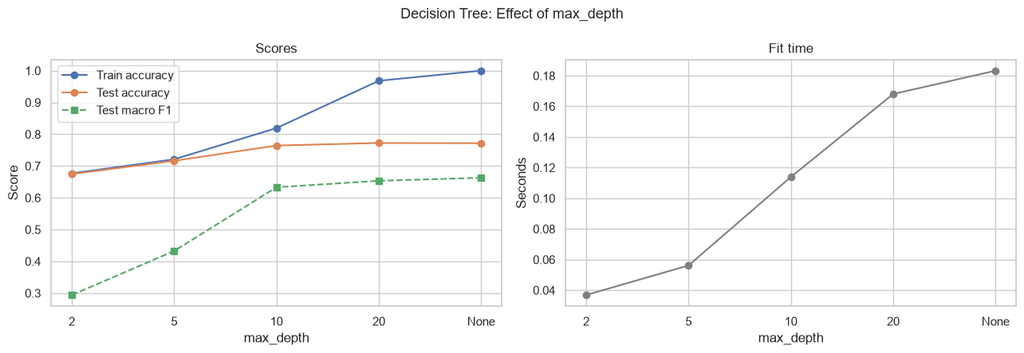

|  | max_depth | Train Accuracy | Test Accuracy | Macro Precision | Macro Recall | Macro F1 | Fit Time (s) | Predict Time (s) |
| --- | --- | --- | --- | --- | --- | --- | --- | --- |
| 0 | 2 | 0.6769 | 0.6746 | 0.2768 | 0.3148 | 0.2942 | 0.0369 | 0.0047 |
| 1 | 5 | 0.7211 | 0.7164 | 0.5676 | 0.4279 | 0.4326 | 0.0562 | 0.0023 |
| 2 | 10 | 0.8193 | 0.7644 | 0.7162 | 0.5949 | 0.6331 | 0.1139 | 0.0027 |
| 3 | 20 | 0.9682 | 0.7724 | 0.6520 | 0.6567 | 0.6535 | 0.1680 | 0.0028 |
| 4 | None | 1.0000 | 0.7718 | 0.6518 | 0.6755 | 0.6629 | 0.1833 | 0.0028 |

```python
# Decision Tree sweep 1: max_depth

# vary max_depth to see how it affects overfitting and underfitting
dt_depth_values = [2, 5, 10, 20, None]

dt_depth_sweep = run_sweep(
    lambda d: DecisionTreeClassifier(max_depth=d, random_state=RANDOM_STATE),
    "max_depth",
    dt_depth_values,
)

plot_sweep(dt_depth_sweep, "max_depth", "Decision Tree: Effect of max_depth")
dt_depth_sweep.round(4)
```

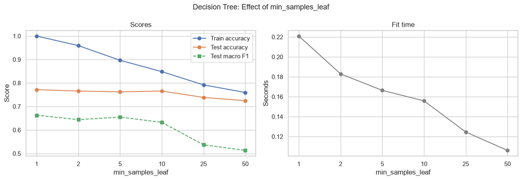

|  | min_samples_leaf | Train Accuracy | Test Accuracy | Macro Precision | Macro Recall | Macro F1 | Fit Time (s) | Predict Time (s) |
| --- | --- | --- | --- | --- | --- | --- | --- | --- |
| 0 | 1 | 1.0000 | 0.7718 | 0.6518 | 0.6755 | 0.6629 | 0.2209 | 0.0035 |
| 1 | 2 | 0.9593 | 0.7658 | 0.6709 | 0.6270 | 0.6442 | 0.1829 | 0.0029 |
| 2 | 5 | 0.8967 | 0.7624 | 0.6744 | 0.6399 | 0.6548 | 0.1663 | 0.0027 |
| 3 | 10 | 0.8484 | 0.7658 | 0.6565 | 0.6167 | 0.6326 | 0.1558 | 0.0027 |
| 4 | 25 | 0.7920 | 0.7386 | 0.6119 | 0.5087 | 0.5371 | 0.1245 | 0.0026 |
| 5 | 50 | 0.7596 | 0.7248 | 0.5659 | 0.5033 | 0.5130 | 0.1061 | 0.0025 |

```python
# Decision Tree sweep 2: min_samples_leaf
# vary min_samples_leaf to see how it affects overfitting and underfitting
dt_leaf_values = [1, 2, 5, 10, 25, 50]

dt_leaf_sweep = run_sweep(
    lambda n: DecisionTreeClassifier(min_samples_leaf=n, random_state=RANDOM_STATE),
    "min_samples_leaf",
    dt_leaf_values,
)

plot_sweep(dt_leaf_sweep, "min_samples_leaf", "Decision Tree: Effect of min_samples_leaf")
dt_leaf_sweep.round(4)
```

```python
# Decision Tree grid search

dt_grid = GridSearchCV(
    DecisionTreeClassifier(random_state=RANDOM_STATE),
    param_grid={
        "max_depth": [5, 10, 15, 20, None],
        "min_samples_leaf": [1, 2, 5, 10],
    },
    scoring=cv_scoring,
    cv=cv,
    n_jobs=-1,
)
dt_grid.fit(X_train, y_train)

print("Best parameters:", dt_grid.best_params_)
print(f"Best mean CV macro F1: {dt_grid.best_score_:.4f}")
display(show_top_cv_results(dt_grid))

# Score the best combination on the test set with the same evaluation function as every other model
summary_results["Tuned Decision Tree"] = evaluate_model(dt_grid.best_estimator_, X_train, y_train, X_test, y_test)
pd.Series(summary_results["Tuned Decision Tree"]).round(4).to_frame("Tuned DT (test set)")
```

```
Best parameters: {'max_depth': None, 'min_samples_leaf': 2}
Best mean CV macro F1: 0.6226
```

|  | Parameters | Mean CV Macro F1 | Std CV Macro F1 | Mean Fit Time (s) |
| --- | --- | --- | --- | --- |
| 0 | max_depth=None, min_samples_leaf=2 | 0.6226 | 0.0393 | 0.2993 |
| 1 | max_depth=None, min_samples_leaf=1 | 0.6193 | 0.0198 | 0.3078 |
| 2 | max_depth=20, min_samples_leaf=2 | 0.6182 | 0.0387 | 0.3559 |
| 3 | max_depth=20, min_samples_leaf=1 | 0.6113 | 0.0202 | 0.3489 |
| 4 | max_depth=15, min_samples_leaf=1 | 0.6087 | 0.0244 | 0.2620 |

|  | Tuned DT (test set) |
| --- | --- |
| Train Accuracy | 0.9593 |
| Test Accuracy | 0.7658 |
| Macro Precision | 0.6709 |
| Macro Recall | 0.6270 |
| Macro F1 | 0.6442 |
| Fit Time (s) | 0.1825 |
| Predict Time (s) | 0.0030 |

### IIC: Random Forest (RF)

RF1

- n_estimators is the number of trees in the forest
- Each tree is trained on a bootstrap sample of the rows and only looks at a random subset of features at each split
- The forest predicts by majority vote, so more trees should make predictions more stable, but training time should grow roughly linearly with the number of trees

RF2

- Unlike a single tree, a forest of fully grown trees often does not overfit as badly, because averaging many different trees cancels out some of their individual mistakes
- This sweep checks whether limiting depth still helps. n_estimators is held at 100 so only max_depth changes

RF Grid Search

- GridSearchCV tries every combination of the two settings and scores each one with 5-fold cross-validation on the training set only

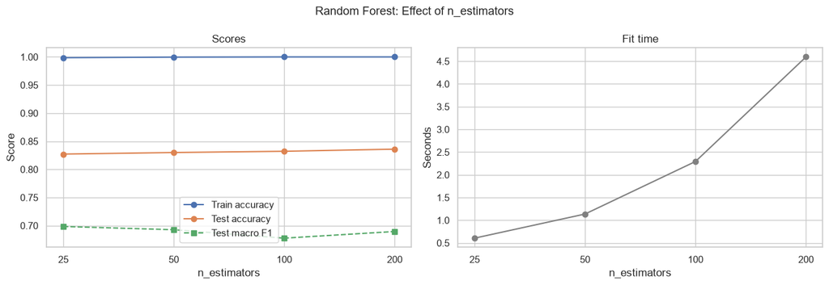

|  | n_estimators | Train Accuracy | Test Accuracy | Macro Precision | Macro Recall | Macro F1 | Fit Time (s) | Predict Time (s) |
| --- | --- | --- | --- | --- | --- | --- | --- | --- |
| 0 | 25 | 0.9987 | 0.8272 | 0.8206 | 0.6484 | 0.6984 | 0.6054 | 0.0237 |
| 1 | 50 | 0.9997 | 0.8300 | 0.8300 | 0.6413 | 0.6927 | 1.1366 | 0.0444 |
| 2 | 100 | 1.0000 | 0.8322 | 0.8006 | 0.6318 | 0.6777 | 2.2934 | 0.0894 |
| 3 | 200 | 1.0000 | 0.8360 | 0.8238 | 0.6408 | 0.6895 | 4.5947 | 0.1742 |

```python
# Random Forest sweep 1: n_estimators
# define a list of values to try for the number of trees in the forest
rf_tree_values = [25, 50, 100, 200]

rf_trees_sweep = run_sweep(
    lambda n: RandomForestClassifier(n_estimators=n, random_state=RANDOM_STATE),
    "n_estimators",
    rf_tree_values,
)

plot_sweep(rf_trees_sweep, "n_estimators", "Random Forest: Effect of n_estimators")
rf_trees_sweep.round(4)
```

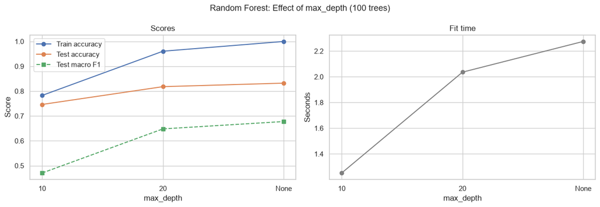

|  | max_depth | Train Accuracy | Test Accuracy | Macro Precision | Macro Recall | Macro F1 | Fit Time (s) | Predict Time (s) |
| --- | --- | --- | --- | --- | --- | --- | --- | --- |
| 0 | 10 | 0.7827 | 0.7464 | 0.8397 | 0.4435 | 0.4706 | 1.2517 | 0.0423 |
| 1 | 20 | 0.9607 | 0.8180 | 0.8274 | 0.5995 | 0.6480 | 2.0357 | 0.0792 |
| 2 | None | 1.0000 | 0.8322 | 0.8006 | 0.6318 | 0.6777 | 2.2746 | 0.0927 |

```python
# Random Forest sweep 2: max_depth
# define a list of values to try for the maximum depth of each tree in the forest
rf_depth_values = [10, 20, None]

rf_depth_sweep = run_sweep(
    lambda d: RandomForestClassifier(n_estimators=100, max_depth=d, random_state=RANDOM_STATE),
    "max_depth",
    rf_depth_values,
)

plot_sweep(rf_depth_sweep, "max_depth", "Random Forest: Effect of max_depth (100 trees)")
rf_depth_sweep.round(4)
```

```python
# Random Forest grid search over both settings (4 x 3 = 12 combinations, 60 fits with 5 folds)
rf_grid = GridSearchCV(
    RandomForestClassifier(random_state=RANDOM_STATE),
    param_grid={
        "n_estimators": rf_tree_values,
        "max_depth": rf_depth_values,
    },
    scoring=cv_scoring,
    cv=cv,
    n_jobs=-1,
)
rf_grid.fit(X_train, y_train)

print("Best parameters:", rf_grid.best_params_)
print(f"Best mean CV macro F1: {rf_grid.best_score_:.4f}")
display(show_top_cv_results(rf_grid))

summary_results["Tuned Random Forest"] = evaluate_model(rf_grid.best_estimator_, X_train, y_train, X_test, y_test)
pd.Series(summary_results["Tuned Random Forest"]).round(4).to_frame("Tuned RF (test set)")
```

```
Best parameters: {'max_depth': None, 'n_estimators': 200}
Best mean CV macro F1: 0.6900
```

|  | Parameters | Mean CV Macro F1 | Std CV Macro F1 | Mean Fit Time (s) |
| --- | --- | --- | --- | --- |
| 0 | max_depth=None, n_estimators=200 | 0.6900 | 0.0285 | 5.6212 |
| 1 | max_depth=None, n_estimators=100 | 0.6882 | 0.0264 | 3.7450 |
| 2 | max_depth=None, n_estimators=50 | 0.6853 | 0.0335 | 1.9104 |
| 3 | max_depth=None, n_estimators=25 | 0.6830 | 0.0294 | 0.9705 |
| 4 | max_depth=20, n_estimators=200 | 0.6745 | 0.0312 | 6.7439 |

|  | Tuned RF (test set) |
| --- | --- |
| Train Accuracy | 1.0000 |
| Test Accuracy | 0.8360 |
| Macro Precision | 0.8238 |
| Macro Recall | 0.6408 |
| Macro F1 | 0.6895 |
| Fit Time (s) | 4.6827 |
| Predict Time (s) | 0.1735 |

### II D: Support Vector Machine (SVM)

SVM 1: C varies, gamma constant, and using both linear and RBF kernels

- The SVM is always built as a pipeline: StandardScaler first, then SVC
- The scaler rescales every feature to mean 0 and standard deviation 1 (see Section I C for why SVM needs this)
- Keeping the scaler inside the pipeline means it is fit only on the training rows, including inside each cross-validation fold, so no information from the test rows leaks into training
- C controls how much the SVM is penalized for misclassifying training points
- A small C allows more mistakes and gives a smoother, simpler boundary, while a large C tries to classify every training point correctly and can overfit
- Linear kernel: a short C sweep for comparison only
- The linear kernel can only draw straight boundaries between classes, so it is a reference point for checking whether the curved boundaries of the RBF kernel are actually needed
- The linear kernel is not tuned any further after this sweep
- The RBF kernel can draw curved boundaries, so it is the kernel that gets tuned further in the grid search

SVM 2: Grid Search varying C and gamma and using RBF kernel only

- gamma controls how far the influence of a single training point reaches
- A small gamma lets each point influence a wide area (smoother boundary), while a large gamma means each point only affects its close neighbors (a very wiggly boundary that can overfit)
- "scale" is sklearn's default, which is 1 / (number of features * variance of X). After standardizing, the variance is 1, so "scale" works out to about 1/54 = 0.019
- C = 0.1 was left out of the grid because the sweep above already showed it scoring far below the larger values

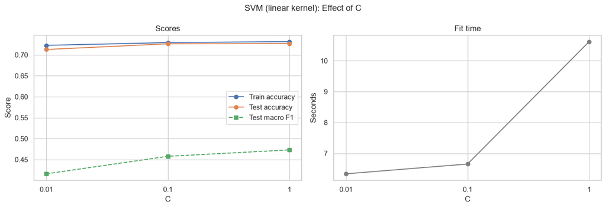

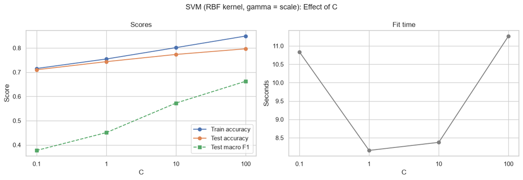

|  | kernel | C | Train Accuracy | Test Accuracy | Macro Precision | Macro Recall | Macro F1 | Fit Time (s) | Predict Time (s) |
| --- | --- | --- | --- | --- | --- | --- | --- | --- | --- |
| 0 | linear | 0.01 | 0.7227 | 0.7128 | 0.5052 | 0.4396 | 0.4160 | 6.3377 | 1.5419 |
| 1 | linear | 0.1 | 0.7293 | 0.7264 | 0.5139 | 0.4630 | 0.4579 | 6.6551 | 1.4215 |
| 2 | linear | 1 | 0.7315 | 0.7268 | 0.5608 | 0.4716 | 0.4731 | 10.6196 | 1.5227 |
| 3 | rbf | 0.1 | 0.7153 | 0.7102 | 0.3897 | 0.3914 | 0.3772 | 10.8371 | 5.3368 |
| 4 | rbf | 1 | 0.7545 | 0.7436 | 0.5532 | 0.4549 | 0.4508 | 8.1563 | 4.6200 |
| 5 | rbf | 10 | 0.8015 | 0.7734 | 0.7094 | 0.5450 | 0.5728 | 8.3756 | 4.1548 |
| 6 | rbf | 100 | 0.8493 | 0.7966 | 0.7439 | 0.6333 | 0.6627 | 11.2683 | 3.8063 |

```python
# SVM sweep 1: C varies, and both linear and RBF kernels are tested.
def build_svm(kernel, C, gamma="scale", class_weight=None):
    """Return an unfitted StandardScaler + SVC pipeline."""
    return Pipeline([
        ("scaler", StandardScaler()),
        ("svc", SVC(kernel=kernel, C=C, gamma=gamma, class_weight=class_weight)),
    ])

# Linear kernel: C sweep
# initially attempted to sweep over C=10 and C=100, but the linear kernel SVM took too long to train on 20k rows, so the sweep was limited to smaller values
linear_C_values = [0.01, 0.1, 1]
svm_linear_sweep = run_sweep(lambda C: build_svm("linear", C), "C", linear_C_values)
plot_sweep(svm_linear_sweep, "C", "SVM (linear kernel): Effect of C")

# RBF kernel: C sweep with gamma held at its default value ("scale"). RBF kernel was efficient enough to allow a wider range of C values to be tested
rbf_C_values = [0.1, 1, 10, 100]
svm_rbf_sweep = run_sweep(lambda C: build_svm("rbf", C), "C", rbf_C_values)
plot_sweep(svm_rbf_sweep, "C", "SVM (RBF kernel, gamma = scale): Effect of C")

# Label the rows with their kernel so both sweeps can share one table
svm_linear_sweep.insert(0, "kernel", "linear")
svm_rbf_sweep.insert(0, "kernel", "rbf")
svm_sweep = pd.concat([svm_linear_sweep, svm_rbf_sweep], ignore_index=True)
svm_sweep.round(4)
```

```
Best parameters: {'svc__C': 100, 'svc__gamma': 0.1}
Best mean CV macro F1: 0.6871
```

|  | Parameters | Mean CV Macro F1 | Std CV Macro F1 | Mean Fit Time (s) |
| --- | --- | --- | --- | --- |
| 0 | C=100, gamma=0.1 | 0.6871 | 0.0098 | 33.0124 |
| 1 | C=10, gamma=0.1 | 0.6682 | 0.0235 | 30.7486 |
| 2 | C=100, gamma=scale | 0.6638 | 0.0237 | 26.7839 |
| 3 | C=10, gamma=1 | 0.6131 | 0.0155 | 138.7099 |
| 4 | C=100, gamma=1 | 0.6126 | 0.0159 | 76.3060 |
| 5 | C=10, gamma=scale | 0.5885 | 0.0191 | 24.6467 |
| 6 | C=1, gamma=0.1 | 0.5647 | 0.0195 | 32.4373 |
| 7 | C=1, gamma=1 | 0.5319 | 0.0338 | 135.6596 |
| 8 | C=1, gamma=scale | 0.4810 | 0.0193 | 27.6242 |

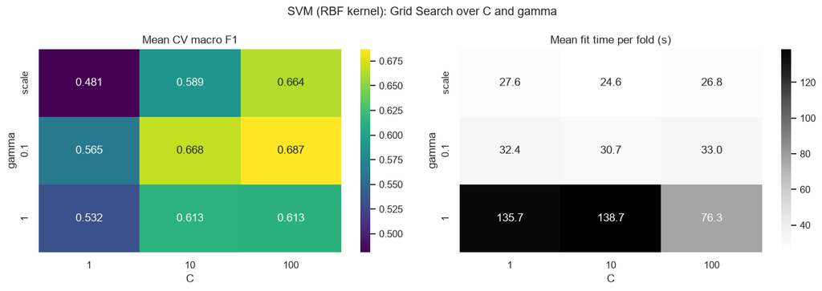

|  | Tuned SVM (test set) |
| --- | --- |
| Train Accuracy | 0.9420 |
| Test Accuracy | 0.8158 |
| Macro Precision | 0.7168 |
| Macro Recall | 0.6774 |
| Macro F1 | 0.6937 |
| Fit Time (s) | 15.5410 |
| Predict Time (s) | 3.6014 |

```python
# SVM grid search: C and gamma for the RBF kernel (3 x 3 = 9 combinations, 45 fits with 5 folds)
# Inside a pipeline, each setting is named "<step name>__<parameter>", so C for the SVC step is written as "svc__C"
svm_grid_C_values = [1, 10, 100]            # C values limited due to long training times for larger values. The RBF kernel is more sensitive to C than the linear kernel, so the range of values is shifted up.
svm_gamma_values = ["scale", 0.1, 1]        # "scale" is the default value, and 0.1 and 1 are chosen to be roughly one order of magnitude smaller and larger than the default

svm_grid = GridSearchCV(
    build_svm("rbf", 1),   # the starting C doesn't matter, the grid replaces it
    param_grid={
        "svc__C": svm_grid_C_values,
        "svc__gamma": svm_gamma_values,
    },
    scoring=cv_scoring,
    cv=cv,
    n_jobs=-1,
)
svm_grid.fit(X_train, y_train)

print("Best parameters:", svm_grid.best_params_)
print(f"Best mean CV macro F1: {svm_grid.best_score_:.4f}")
display(show_top_cv_results(svm_grid, n=9))

# Heatmaps of the grid results: mean CV macro F1 and mean fit time for every C and gamma combination
# The C and gamma values are turned into text so "scale" and the numbers can share one axis
svm_cv_table = pd.DataFrame(svm_grid.cv_results_)
svm_cv_table["C"] = svm_cv_table["param_svc__C"].map(str)
svm_cv_table["gamma"] = svm_cv_table["param_svc__gamma"].map(str)
gamma_order = [str(g) for g in svm_gamma_values]
C_order = [str(c) for c in svm_grid_C_values]

fig, (ax_f1, ax_time) = plt.subplots(1, 2, figsize=(13, 4.5))
for ax, value_col, title, fmt, cmap in [
    (ax_f1, "mean_test_score", "Mean CV macro F1", ".3f", "viridis"),
    (ax_time, "mean_fit_time", "Mean fit time per fold (s)", ".1f", "Greys"),
]:
    table = svm_cv_table.pivot(index="gamma", columns="C", values=value_col).reindex(index=gamma_order, columns=C_order)
    sns.heatmap(table, annot=True, fmt=fmt, cmap=cmap, ax=ax)
    ax.set_title(title)
fig.suptitle("SVM (RBF kernel): Grid Search over C and gamma", fontsize=13)
plt.tight_layout()
plt.show()

summary_results["Tuned SVM"] = evaluate_model(svm_grid.best_estimator_, X_train, y_train, X_test, y_test)
pd.Series(summary_results["Tuned SVM"]).round(4).to_frame("Tuned SVM (test set)")
```

### IIE: Class Weighting: Default vs. Balanced

- By default every training row counts the same, so the models are mostly rewarded for getting the two large classes right
- class_weight="balanced" gives each class a weight of n_samples / (n_classes * class_count), so mistakes on rare classes cost more. For example, Cottonwood/Willow makes up about 0.5% of the rows, so each of its rows counts roughly 30 times as much as an average row
- The expected tradeoff is better recall on the rare cover types in exchange for a little overall accuracy on the large classes
- Each model keeps the settings chosen by its grid search above, so class_weight is the only thing that changes

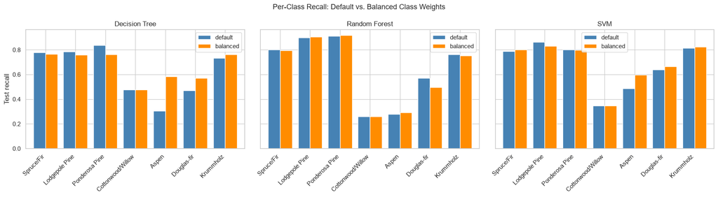

```
class_weight setting kept for each model (higher CV macro F1): {'Decision Tree': 'balanced', 'Random Forest': None, 'SVM': None}
```

| Model | class_weight | Mean CV Macro F1 | Std CV Macro F1 | Train Accuracy | Test Accuracy | Macro Precision | Macro Recall | Macro F1 | Fit Time (s) | Predict Time (s) |
| --- | --- | --- | --- | --- | --- | --- | --- | --- | --- | --- |
| Decision Tree | default | 0.6226 | 0.0393 | 0.9593 | 0.7658 | 0.6709 | 0.6270 | 0.6442 | 0.1737 | 0.0029 |
|  | balanced | 0.6257 | 0.0292 | 0.9537 | 0.7516 | 0.6184 | 0.6691 | 0.6415 | 0.1769 | 0.0031 |
| Random Forest | default | 0.6900 | 0.0285 | 1.0000 | 0.8360 | 0.8238 | 0.6408 | 0.6895 | 4.5726 | 0.1753 |
|  | balanced | 0.6826 | 0.0286 | 1.0000 | 0.8356 | 0.8094 | 0.6316 | 0.6796 | 4.4766 | 0.1850 |
| SVM | default | 0.6871 | 0.0098 | 0.9420 | 0.8158 | 0.7168 | 0.6774 | 0.6937 | 15.7550 | 3.6221 |
|  | balanced | 0.6804 | 0.0140 | 0.9205 | 0.8068 | 0.6799 | 0.6951 | 0.6868 | 12.1083 | 3.8457 |

```python
# Class weighting comparison

# Functions that rebuild each tuned model with a given class_weight setting
weighting_builders = {
    "Decision Tree": lambda cw: DecisionTreeClassifier(**dt_grid.best_params_, class_weight=cw, random_state=RANDOM_STATE),
    "Random Forest": lambda cw: RandomForestClassifier(**rf_grid.best_params_, class_weight=cw, random_state=RANDOM_STATE),
    "SVM": lambda cw: build_svm("rbf", svm_grid.best_params_["svc__C"], svm_grid.best_params_["svc__gamma"], class_weight=cw),
}
# In the SVM pipeline the setting belongs to the "svc" step, so its grid name has the "svc__" prefix
weight_param_names = {"Decision Tree": "class_weight", "Random Forest": "class_weight", "SVM": "svc__class_weight"}

class_labels = list(cover_type_names.keys())   # the numeric labels 1-7, in order
cw_settings = [None, "balanced"]

cw_rows = []                 # one row per model per weighting setting
recall_tables = {}           # per-class recall for each model, used for the plot below
class_weight_choice = {}     # the setting with the higher CV macro F1, carried forward to Section III

for name, build in weighting_builders.items():
    # Part 1: cross-validated comparison on the training set, using the same 5 folds as the tuning above
    param = weight_param_names[name]
    cw_grid = GridSearchCV(build(None), {param: cw_settings}, scoring=cv_scoring, cv=cv, n_jobs=-1)
    cw_grid.fit(X_train, y_train)
    cv_res = pd.DataFrame(cw_grid.cv_results_)   # rows come back in the same order as cw_settings
    class_weight_choice[name] = cw_grid.best_params_[param]

    # Part 2: fit each version on the full training set and score it on the test set
    recalls = {}
    for i, cw in enumerate(cw_settings):
        label = "default" if cw is None else "balanced"
        model = build(cw)
        metrics = evaluate_model(model, X_train, y_train, X_test, y_test)

        # average=None returns one recall value per class instead of a single average, which shows exactly which cover types gain or lose from the weighting
        _, class_recall, _, _ = precision_recall_fscore_support(y_test, model.predict(X_test), labels=class_labels, average=None, zero_division=0)
        recalls[label] = class_recall

        cw_rows.append({
            "Model": name,
            "class_weight": label,
            "Mean CV Macro F1": cv_res.loc[i, "mean_test_score"],
            "Std CV Macro F1": cv_res.loc[i, "std_test_score"],
            **metrics,
        })

    recall_tables[name] = pd.DataFrame(recalls, index=cover_type_order)

# Plot per-class test recall, default vs. balanced, for each model
fig, axes = plt.subplots(1, 3, figsize=(18, 5), sharey=True)
for ax, (name, table) in zip(axes, recall_tables.items()):
    table.plot.bar(ax=ax, color=["steelblue", "darkorange"], width=0.8)
    ax.set_title(name)
    ax.set_xlabel("")
    ax.set_ylabel("Test recall")
    ax.tick_params(axis="x", rotation=45)
    plt.setp(ax.get_xticklabels(), ha="right")
fig.suptitle("Per-Class Recall: Default vs. Balanced Class Weights", fontsize=13)
plt.tight_layout()
plt.show()

print("class_weight setting kept for each model (higher CV macro F1):", class_weight_choice)
cw_results = pd.DataFrame(cw_rows).set_index(["Model", "class_weight"])
cw_results.round(4)
```

### Section II Summary

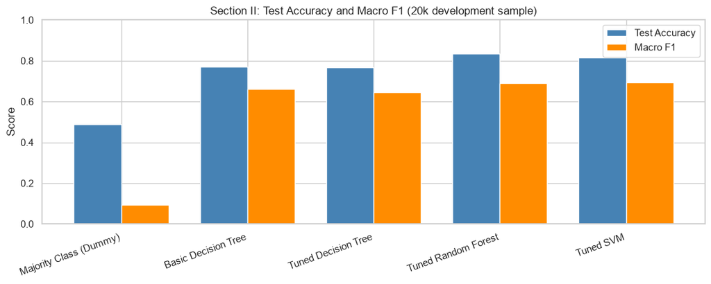

```
Decision Tree: {'max_depth': None, 'min_samples_leaf': 2, 'class_weight': 'balanced'}
Random Forest: {'max_depth': None, 'n_estimators': 200, 'class_weight': None}
SVM: {'kernel': 'rbf', 'C': 100, 'gamma': 0.1, 'class_weight': None}
```

|  | Train Accuracy | Test Accuracy | Macro Precision | Macro Recall | Macro F1 | Fit Time (s) | Predict Time (s) |
| --- | --- | --- | --- | --- | --- | --- | --- |
| Majority Class (Dummy) | 0.4876 | 0.4876 | 0.0697 | 0.1429 | 0.0937 | 0.0020 | 0.0006 |
| Basic Decision Tree | 1.0000 | 0.7718 | 0.6518 | 0.6755 | 0.6629 | 0.1922 | 0.0035 |
| Tuned Decision Tree | 0.9593 | 0.7658 | 0.6709 | 0.6270 | 0.6442 | 0.1825 | 0.0030 |
| Tuned Random Forest | 1.0000 | 0.8360 | 0.8238 | 0.6408 | 0.6895 | 4.6827 | 0.1735 |
| Tuned SVM | 0.9420 | 0.8158 | 0.7168 | 0.6774 | 0.6937 | 15.5410 | 3.6014 |

```python
# Combine the baselines and the tuned models into one table of test set results
section2_summary = pd.DataFrame(summary_results).T

# Side by side bar chart of test accuracy and test macro F1 for every model
fig, ax = plt.subplots(figsize=(11, 4.5))
section2_summary[["Test Accuracy", "Macro F1"]].plot.bar(ax=ax, color=["steelblue", "darkorange"], width=0.75)
ax.set_title("Section II: Test Accuracy and Macro F1 (20k development sample)")
ax.set_ylabel("Score")
ax.set_ylim(0, 1)
ax.tick_params(axis="x", rotation=20)
plt.setp(ax.get_xticklabels(), ha="right")
plt.tight_layout()
plt.show()

# Save the chosen settings for each model so Section III can build its models from this dictionary
# instead of copying numbers by hand. The SVM names drop the "svc__" prefix because Section III passes them straight to build_svm()
best_params = {
    "Decision Tree": {**dt_grid.best_params_, "class_weight": class_weight_choice["Decision Tree"]},
    "Random Forest": {**rf_grid.best_params_, "class_weight": class_weight_choice["Random Forest"]},
    "SVM": {
        "kernel": "rbf",
        "C": svm_grid.best_params_["svc__C"],
        "gamma": svm_grid.best_params_["svc__gamma"],
        "class_weight": class_weight_choice["SVM"],
    },
}
for name, params in best_params.items():
    print(f"{name}: {params}")

section2_summary.round(4)
```

### Section II Results Discussion

#### Decision Tree

The basic Decision Tree reached 100% training accuracy and about 0.772 test accuracy, which is a strong indication that the unrestricted tree was overfitting the training data. The full tree reached a depth of 33 with more than 2,300 leaves. The parameter experiments showed that restricting tree complexity can reduce this overfitting, although the best grid-search combination did not improve the test results. The selected combination of max_depth=None and min_samples_leaf=2 produced a mean cross-validation macro F1 of about 0.623. However, the tuned tree had slightly lower accuracy and macro F1 on the test set than the basic tree. This suggests that reducing tree complexity improved the train/test gap but also removed some useful predictive ability.

Class weighting was also tested because of the target imbalance. For the Decision Tree, class_weight="balanced" produced a slightly higher cross-validation macro F1 than the default weighting (0.626 compared with 0.623). The balanced version also increased macro recall, although this came at the cost of lower precision and overall test accuracy. Because the project is concerned with performance across all seven cover types rather than only the most common classes, the balanced setting will be carried into Section III and evaluated over repeated samples before deciding whether it is actually preferable.

#### Random Forest

The Random Forest experiments showed that increasing the number of trees improved performance, but the improvement became smaller as additional trees were added. The best grid-search result used 200 trees with no maximum depth and achieved a mean cross-validation macro F1 of 0.690. However, 100 trees produced a very similar score of 0.688 while requiring noticeably less training time. This suggests that the benefit of adding trees begins to level off somewhere between 100 and 200 trees. For Section III, 200 trees will be used because it produced the best cross-validation result. The difference in computational cost will be considered later in the scalability analysis (Section IV).

The Random Forest performed better than either Decision Tree on the Section II test set, with about 0.836 accuracy and 0.690 macro F1. Training accuracy was still 1.0, so the model is fitting the training data extremely closely, but its test performance suggests that averaging many trees improves generalization compared with a single unrestricted tree. Using balanced class weights did not improve Random Forest performance. The default weighting produced a higher cross-validation macro F1 and higher test macro F1, so the default weighting will be retained.

#### Support Vector Machine

The initial SVM comparison showed that the nonlinear RBF kernel was more appropriate for this dataset than the linear kernel, so the RBF model was used for further tuning of C and gamma. The best combination found by GridSearchCV was C=100 and gamma=0.1, with a mean cross-validation macro F1 of about 0.687. The test-set macro F1 of 0.694 was slightly higher than the Random Forest result, although its overall accuracy of about 0.816 was lower. This is important because it shows that the model ranking depends on which metric is emphasized. Random Forest performs better by overall accuracy, while SVM performs slightly better when all seven classes are weighted equally through macro F1.

The main disadvantage of SVM in these preliminary tests was computational cost. The tuned SVM required about 15.5 seconds to fit and 3.6 seconds to make predictions on the Section II sample, compared with about 4.7 seconds and 0.17 seconds for Random Forest. Balanced class weighting increased recall somewhat but reduced cross-validation and test macro F1, so the default class weighting will be used in Section III. These results suggest that SVM may be competitive in predictive performance but could become difficult to scale as the sample size increases.

## Section III: Repeated Model Evaluation on Stratified Random Samples

The final model settings selected in Section II will be carried forward into the repeated testing in Section III.

- The Decision Tree will use max_depth=None, min_samples_leaf=2, and class_weight="balanced".
- The Random Forest will use max_depth=None, n_estimators=200, and the default class weighting.
- The SVM will use an RBF kernel with C=100, gamma=0.1, and the default class weighting.

These settings were selected based on the Section II cross-validation results and will now be tested across multiple stratified random samples to determine whether their performance is stable and consistent. Each entry is a function that takes a seed and returns a new, unfitted model. The tuned models get their settings from Section II. The seed is also passed to the tree models, so the variation across trials includes both the different data samples and the randomness inside the models. The SVM has no randomness of its own, so its variation comes only from the data.

#### III A: Trial Setup

```python
# Section III setup: trial settings and the models that will be rebuilt in every trial

# Define best hyperparameter settings for each model, based on the tuning results from Section II
best_params = {
    "Decision Tree": {"max_depth": None, "min_samples_leaf": 2, "class_weight": "balanced"},
    "Random Forest": {"max_depth": None, "n_estimators": 200, "class_weight": None},
    "SVM": {"kernel": "rbf", "C": 100, "gamma": 0.1, "class_weight": None},
}

# Same SVM builder as in Section II: StandardScaler first, then SVC, so the features are scaled inside every trial
def build_svm(kernel, C, gamma="scale", class_weight=None):
    """Return an unfitted StandardScaler + SVC pipeline."""
    return Pipeline([
        ("scaler", StandardScaler()),
        ("svc", SVC(kernel=kernel, C=C, gamma=gamma, class_weight=class_weight)),
    ])

# The numeric cover type labels 1-7 in order, used for the per-class report and the confusion matrices
class_labels = list(cover_type_names.keys())

# Every trial uses the same sample size as the Section II development sample, so the results here can be compared directly with the tuning results
n_trials = 20
trial_sample_size = 20_000

# Draw one seed per trial from a random generator that starts at RANDOM_STATE
# This way the seeds are different from each other but the whole experiment can still be reproduced by rerunning the notebook
seed_generator = np.random.default_rng(RANDOM_STATE)
trial_seeds = seed_generator.integers(0, 100_000, size=n_trials).tolist()

# Given a seed, each lambda function returns a new, unfitted model with the tuned settings from Section II
trial_models = {
    "Majority Class (Dummy)": lambda seed: DummyClassifier(strategy="most_frequent"),
    "Basic Decision Tree": lambda seed: DecisionTreeClassifier(random_state=seed),
    "Tuned Decision Tree": lambda seed: DecisionTreeClassifier(**best_params["Decision Tree"], random_state=seed),
    "Tuned Random Forest": lambda seed: RandomForestClassifier(**best_params["Random Forest"], random_state=seed),
    "Tuned SVM": lambda seed: build_svm(**best_params["SVM"]),
}

# Only the three tuned models get per-class reports and confusion matrices later on, since the baselines are only there for comparison
tuned_model_names = ["Tuned Decision Tree", "Tuned Random Forest", "Tuned SVM"]

print(f"{n_trials} trials of {trial_sample_size:,} rows each")
print("Trial seeds:", trial_seeds)
for name, params in best_params.items():
    print(f"{name}: {params}")
```

```
20 trials of 20,000 rows each
Trial seeds: [8925, 77395, 65457, 43887, 43301, 85859, 8594, 69736, 20146, 9417, 52647, 97562, 73575, 76113, 71747, 78606, 51322, 12811, 83974, 45038]
Decision Tree: {'max_depth': None, 'min_samples_leaf': 2, 'class_weight': 'balanced'}
Random Forest: {'max_depth': None, 'n_estimators': 200, 'class_weight': None}
SVM: {'kernel': 'rbf', 'C': 100, 'gamma': 0.1, 'class_weight': None}
```

#### IIIB: Running the Trials

- In each trial, a new stratified sample is drawn and split, and then every model is trained and scored on that same split
- Using the same split for every model in a trial keeps the comparison fair, since no model gets an easier or harder sample than the others

```python
# Run the repeated trials

trial_rows = []   # one row of metrics per model per trial

# Pooled test labels and predictions for each tuned model, across all trials
# These are used for the per-class report and the summed confusion matrices
pooled_true = {name: [] for name in tuned_model_names}
pooled_pred = {name: [] for name in tuned_model_names}

section3_start = time.perf_counter()

for trial, seed in enumerate(trial_seeds, start=1):
    # Draw a new stratified sample and a new stratified 75/25 split using this trial's seed
    trial_sample = get_stratified_sample(df, trial_sample_size, random_state=seed)
    X_tr, X_te, y_tr, y_te = split_features_target(trial_sample, random_state=seed)

    for name, build in trial_models.items():
        model = build(seed)
        metrics = evaluate_model(model, X_tr, y_tr, X_te, y_te)

        # Save the test predictions for the tuned models
        # evaluate_model() doesn't return its predictions, so the fitted model predicts the test set again here
        if name in tuned_model_names:
            pooled_true[name].append(y_te.to_numpy())
            pooled_pred[name].append(model.predict(X_te))

        trial_rows.append({
            "Model": name,
            "Trial": trial,
            "Seed": seed,
            "Sample Size": trial_sample_size,
            **metrics,
            # The gap between train and test accuracy is a simple measure of overfitting
            "Overfit Gap": metrics["Train Accuracy"] - metrics["Test Accuracy"],
            # Record the settings each model used, so the results table is self-explanatory
            "Params": str(best_params.get(name.replace("Tuned ", ""), "default")),
        })

    # Print progress since this loop runs for a while (~20 minutes on a laptop with 8 cores)
    elapsed = time.perf_counter() - section3_start
    print(f"Trial {trial:2d}/{n_trials} done (seed {seed}), {elapsed / 60:.1f} min elapsed")

# Join each model's predictions from all trials into one long array
pooled_true = {name: np.concatenate(arrays) for name, arrays in pooled_true.items()}
pooled_pred = {name: np.concatenate(arrays) for name, arrays in pooled_pred.items()}

trial_results = pd.DataFrame(trial_rows)
trial_results.head(10).round(4)
```

```
Trial  1/20 done (seed 8925), 0.9 min elapsed
Trial  2/20 done (seed 77395), 1.7 min elapsed
Trial  3/20 done (seed 65457), 2.6 min elapsed
Trial  4/20 done (seed 43887), 3.4 min elapsed
Trial  5/20 done (seed 43301), 4.3 min elapsed
Trial  6/20 done (seed 85859), 5.1 min elapsed
Trial  7/20 done (seed 8594), 6.0 min elapsed
Trial  8/20 done (seed 69736), 6.8 min elapsed
Trial  9/20 done (seed 20146), 7.7 min elapsed
Trial 10/20 done (seed 9417), 8.5 min elapsed
Trial 11/20 done (seed 52647), 9.4 min elapsed
Trial 12/20 done (seed 97562), 10.2 min elapsed
Trial 13/20 done (seed 73575), 11.1 min elapsed
Trial 14/20 done (seed 76113), 11.9 min elapsed
Trial 15/20 done (seed 71747), 12.8 min elapsed
Trial 16/20 done (seed 78606), 13.7 min elapsed
Trial 17/20 done (seed 51322), 14.5 min elapsed
Trial 18/20 done (seed 12811), 15.3 min elapsed
Trial 19/20 done (seed 83974), 16.2 min elapsed
Trial 20/20 done (seed 45038), 17.0 min elapsed
```

|  | Model | Trial | Seed | Sample Size | Train Accuracy | Test Accuracy | Macro Precision | Macro Recall | Macro F1 | Fit Time (s) | Predict Time (s) | Overfit Gap | Params |
| --- | --- | --- | --- | --- | --- | --- | --- | --- | --- | --- | --- | --- | --- |
| 0 | Majority Class (Dummy) | 1 | 8925 | 20000 | 0.4876 | 0.4876 | 0.0697 | 0.1429 | 0.0937 | 0.0008 | 0.0001 | 0.0000 | default |
| 1 | Basic Decision Tree | 1 | 8925 | 20000 | 1.0000 | 0.7480 | 0.6360 | 0.6413 | 0.6372 | 0.2200 | 0.0044 | 0.2520 | default |
| 2 | Tuned Decision Tree | 1 | 8925 | 20000 | 0.9523 | 0.7288 | 0.6179 | 0.6524 | 0.6338 | 0.2288 | 0.0033 | 0.2235 | {'max_depth': None, 'min_samples_leaf': 2, 'cl... |
| 3 | Tuned Random Forest | 1 | 8925 | 20000 | 1.0000 | 0.8268 | 0.8102 | 0.6194 | 0.6753 | 5.5909 | 0.2236 | 0.1732 | {'max_depth': None, 'n_estimators': 200, 'clas... |
| 4 | Tuned SVM | 1 | 8925 | 20000 | 0.9405 | 0.8006 | 0.6947 | 0.6659 | 0.6778 | 20.3517 | 4.4356 | 0.1399 | {'kernel': 'rbf', 'C': 100, 'gamma': 0.1, 'cla... |
| 5 | Majority Class (Dummy) | 2 | 77395 | 20000 | 0.4876 | 0.4876 | 0.0697 | 0.1429 | 0.0937 | 0.0015 | 0.0001 | 0.0000 | default |
| 6 | Basic Decision Tree | 2 | 77395 | 20000 | 1.0000 | 0.7532 | 0.6102 | 0.6114 | 0.6097 | 0.2377 | 0.0035 | 0.2468 | default |
| 7 | Tuned Decision Tree | 2 | 77395 | 20000 | 0.9539 | 0.7274 | 0.5847 | 0.6743 | 0.6216 | 0.2327 | 0.0033 | 0.2265 | {'max_depth': None, 'min_samples_leaf': 2, 'cl... |
| 8 | Tuned Random Forest | 2 | 77395 | 20000 | 1.0000 | 0.8290 | 0.8044 | 0.6648 | 0.7114 | 5.7650 | 0.2305 | 0.1710 | {'max_depth': None, 'n_estimators': 200, 'clas... |
| 9 | Tuned SVM | 2 | 77395 | 20000 | 0.9424 | 0.8090 | 0.7179 | 0.7236 | 0.7200 | 19.9710 | 4.3455 | 0.1334 | {'kernel': 'rbf', 'C': 100, 'gamma': 0.1, 'cla... |

#### III C: Mean and Standard Deviation Across Trials

```python
# Summarize the trials: the mean shows typical performance and the standard deviation shows how stable each model is across different samples
summary_metrics = ["Train Accuracy", "Test Accuracy", "Macro F1", "Macro Precision", "Macro Recall",
                   "Overfit Gap", "Fit Time (s)", "Predict Time (s)"]

# Keep the models in the same order they were defined in, instead of alphabetical order
model_order = list(trial_models.keys())

trial_summary = (
    trial_results.groupby("Model")[summary_metrics]
    .agg(["mean", "std"])
    .reindex(model_order)
)
trial_summary.round(4)
```

| Model | Train Accuracy mean | Train Accuracy std | Test Accuracy mean | Test Accuracy std | Macro F1 mean | Macro F1 std | Macro Precision mean | Macro Precision std | Macro Recall mean | Macro Recall std | Overfit Gap mean | Overfit Gap std | Fit Time (s) mean | Fit Time (s) std | Predict Time (s) mean | Predict Time (s) std |
| --- | --- | --- | --- | --- | --- | --- | --- | --- | --- | --- | --- | --- | --- | --- | --- | --- |
| Majority Class (Dummy) | 0.4876 | 0.0000 | 0.4876 | 0.0000 | 0.0937 | 0.0000 | 0.0697 | 0.0000 | 0.1429 | 0.0000 | 0.0000 | 0.0000 | 0.0008 | 0.0002 | 0.0001 | 0.0000 |
| Basic Decision Tree | 1.0000 | 0.0000 | 0.7545 | 0.0035 | 0.6430 | 0.0136 | 0.6430 | 0.0162 | 0.6454 | 0.0149 | 0.2454 | 0.0035 | 0.2194 | 0.0109 | 0.0035 | 0.0003 |
| Tuned Decision Tree | 0.9538 | 0.0014 | 0.7362 | 0.0068 | 0.6282 | 0.0146 | 0.6104 | 0.0182 | 0.6522 | 0.0174 | 0.2177 | 0.0069 | 0.2218 | 0.0113 | 0.0035 | 0.0003 |
| Tuned Random Forest | 1.0000 | 0.0000 | 0.8313 | 0.0066 | 0.7070 | 0.0194 | 0.8212 | 0.0216 | 0.6580 | 0.0218 | 0.1687 | 0.0066 | 5.7357 | 0.3725 | 0.2270 | 0.0075 |
| Tuned SVM | 0.9409 | 0.0021 | 0.8051 | 0.0055 | 0.6984 | 0.0169 | 0.7104 | 0.0206 | 0.6891 | 0.0186 | 0.1358 | 0.0051 | 20.2994 | 0.7154 | 4.4527 | 0.1838 |

#### III D: Distributions of Scores and Training Time

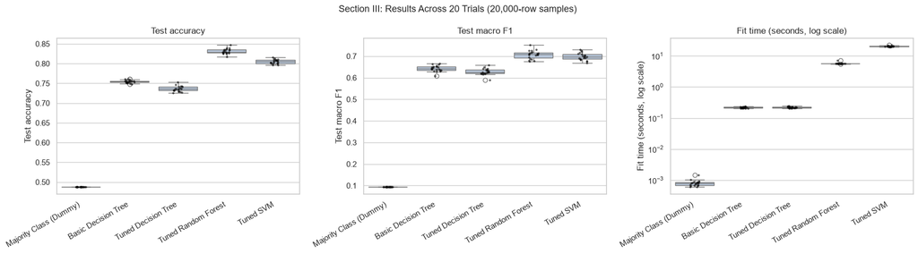

```python
# Boxplots of test accuracy, macro F1, and fit time across the 20 trials
# Each box shows the spread of one model's results, so a short box means the model gives about the same result no matter which sample it gets
fig, axes = plt.subplots(1, 3, figsize=(18, 5))
box_metrics = [
    ("Test Accuracy", "Test accuracy"),
    ("Macro F1", "Test macro F1"),
    ("Fit Time (s)", "Fit time (seconds, log scale)"),
]

for ax, (col, label) in zip(axes, box_metrics):
    sns.boxplot(data=trial_results, x="Model", y=col, order=model_order, ax=ax, color="lightsteelblue")
    # Overlay the individual trials as dots so the actual 20 values are visible, not just the box
    sns.stripplot(data=trial_results, x="Model", y=col, order=model_order, ax=ax, color="black", size=3, alpha=0.6)
    ax.set_title(label)
    ax.set_xlabel("")
    ax.set_ylabel(label)
    ax.tick_params(axis="x", rotation=30)
    plt.setp(ax.get_xticklabels(), ha="right")

# Fit times range from milliseconds (Dummy) to tens of seconds (SVM), so a log scale is needed to see all of them on one plot
axes[2].set_yscale("log")

fig.suptitle(f"Section III: Results Across {n_trials} Trials ({trial_sample_size:,}-row samples)", fontsize=13)
plt.tight_layout()
plt.show()
```

#### III E: Overfitting (Train vs. Test Accuracy)

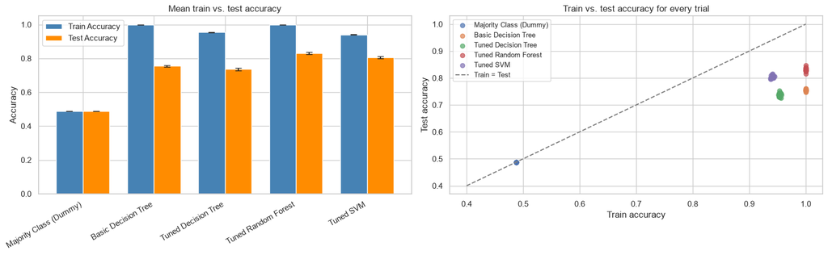

| Model | mean | std |
| --- | --- | --- |
| Majority Class (Dummy) | 0.0000 | 0.0000 |
| Basic Decision Tree | 0.2454 | 0.0035 |
| Tuned Decision Tree | 0.2177 | 0.0069 |
| Tuned Random Forest | 0.1687 | 0.0066 |
| Tuned SVM | 0.1358 | 0.0051 |

```python
# Train vs. test accuracy for each model, averaged over the trials
# Error bars show one standard deviation across the 20 trials
# A tall train bar next to a much shorter test bar means the model fits its training data much better than new data (overfitting)
train_test_means = trial_summary.xs("mean", axis=1, level=1)[["Train Accuracy", "Test Accuracy"]]
train_test_stds = trial_summary.xs("std", axis=1, level=1)[["Train Accuracy", "Test Accuracy"]]

fig, (ax_bars, ax_scatter) = plt.subplots(1, 2, figsize=(16, 5))

train_test_means.plot.bar(ax=ax_bars, yerr=train_test_stds, capsize=4, color=["steelblue", "darkorange"], width=0.75)
ax_bars.set_title("Mean train vs. test accuracy")
ax_bars.set_ylabel("Accuracy")
ax_bars.set_ylim(0, 1.05)
ax_bars.set_xlabel("")
ax_bars.tick_params(axis="x", rotation=30)
plt.setp(ax_bars.get_xticklabels(), ha="right")

# Right plot: one dot per trial, so each model shows up as a cluster
# The dashed line is where train accuracy equals test accuracy, and the further a cluster sits to the right of it, the bigger the overfitting
for name in model_order:
    rows = trial_results[trial_results["Model"] == name]
    ax_scatter.scatter(rows["Train Accuracy"], rows["Test Accuracy"], label=name, alpha=0.7)
ax_scatter.plot([0.4, 1.0], [0.4, 1.0], linestyle="--", color="gray", label="Train = Test")
ax_scatter.set_xlabel("Train accuracy")
ax_scatter.set_ylabel("Test accuracy")
ax_scatter.set_title("Train vs. test accuracy for every trial")
ax_scatter.legend(fontsize=9)

plt.tight_layout()
plt.show()

# Overfitting gap table (mean and standard deviation of train accuracy minus test accuracy)
trial_summary["Overfit Gap"].round(4)
```

#### III F: Per-Class Performance

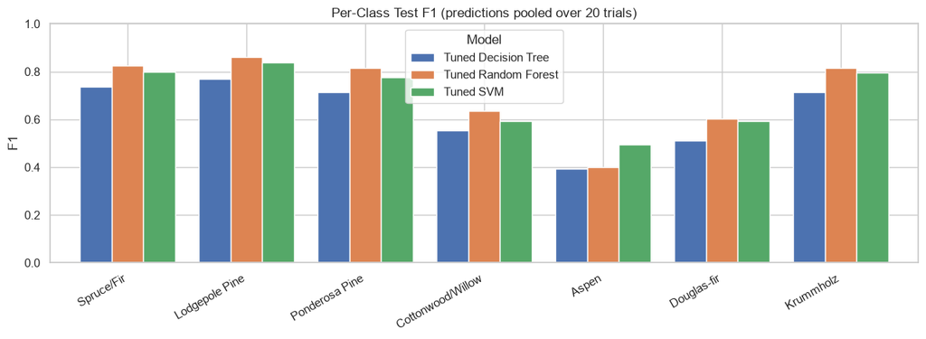

| Model Cover Type | Precision Tuned Decision Tree | Precision Tuned Random Forest | Precision Tuned SVM | Recall Tuned Decision Tree | Recall Tuned Random Forest | Recall Tuned SVM | F1 Tuned Decision Tree | F1 Tuned Random Forest | F1 Tuned SVM |
| --- | --- | --- | --- | --- | --- | --- | --- | --- | --- |
| Spruce/Fir | 0.718 | 0.842 | 0.808 | 0.756 | 0.809 | 0.790 | 0.737 | 0.825 | 0.799 |
| Lodgepole Pine | 0.800 | 0.832 | 0.827 | 0.744 | 0.891 | 0.850 | 0.771 | 0.861 | 0.838 |
| Ponderosa Pine | 0.707 | 0.772 | 0.781 | 0.724 | 0.866 | 0.769 | 0.715 | 0.816 | 0.775 |
| Cottonwood/Willow | 0.520 | 0.809 | 0.608 | 0.592 | 0.522 | 0.582 | 0.554 | 0.635 | 0.594 |
| Aspen | 0.359 | 0.828 | 0.522 | 0.436 | 0.265 | 0.468 | 0.394 | 0.401 | 0.494 |
| Douglas-fir | 0.476 | 0.752 | 0.612 | 0.553 | 0.504 | 0.575 | 0.512 | 0.603 | 0.593 |
| Krummholz | 0.674 | 0.896 | 0.802 | 0.760 | 0.748 | 0.791 | 0.714 | 0.815 | 0.796 |

```python
# Per-class results for the three tuned models, using the test predictions pooled across all 20 trials
# Pooling gives each rare class many more test rows to be scored on (for example, Cottonwood/Willow has only about 24 test rows per trial, but about 480 over 20 trials)
per_class_rows = []
for name in tuned_model_names:
    report = classification_report(
        pooled_true[name], pooled_pred[name],
        labels=class_labels, target_names=cover_type_order,
        output_dict=True, zero_division=0,
    )
    for cover in cover_type_order:
        per_class_rows.append({
            "Model": name,
            "Cover Type": cover,
            "Precision": report[cover]["precision"],
            "Recall": report[cover]["recall"],
            "F1": report[cover]["f1-score"],
            "Test Rows (all trials)": int(report[cover]["support"]),
        })

per_class_results = pd.DataFrame(per_class_rows)

# Grouped bar chart of per-class F1, so it is easy to see which cover types each model struggles with
per_class_f1 = per_class_results.pivot(index="Cover Type", columns="Model", values="F1").reindex(cover_type_order)
fig, ax = plt.subplots(figsize=(12, 4.5))
per_class_f1[tuned_model_names].plot.bar(ax=ax, width=0.8)
ax.set_title(f"Per-Class Test F1 (predictions pooled over {n_trials} trials)")
ax.set_ylabel("F1")
ax.set_ylim(0, 1)
ax.set_xlabel("")
ax.tick_params(axis="x", rotation=30)
plt.setp(ax.get_xticklabels(), ha="right")
plt.tight_layout()
plt.show()

# Wide table with precision, recall, and F1 for each model side by side
per_class_results.pivot(index="Cover Type", columns="Model", values=["Precision", "Recall", "F1"]).reindex(cover_type_order).round(3)
```

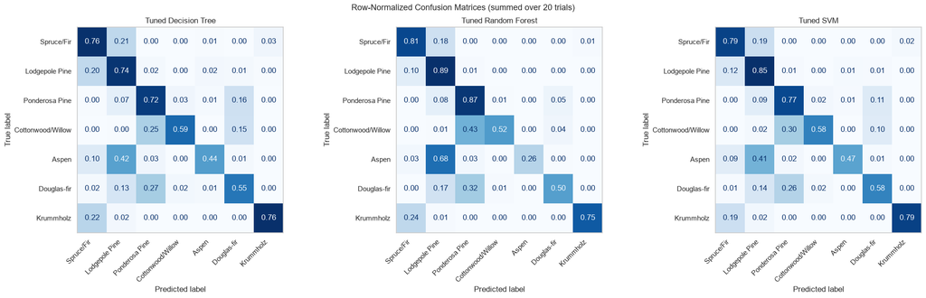

```python
# Confusion matrices for the three tuned models, summed over all 20 trials
# Each row is normalized to add up to 1, so a cell shows the fraction of that true cover type that was predicted as each class
# Normalizing by row is important here, because without it the two big classes would dominate the colors and the rare classes would be hard to read
fig, axes = plt.subplots(1, 3, figsize=(21, 6.5))
for ax, name in zip(axes, tuned_model_names):
    cm = confusion_matrix(pooled_true[name], pooled_pred[name], labels=class_labels, normalize="true")
    ConfusionMatrixDisplay(cm, display_labels=cover_type_order).plot(
        ax=ax, cmap="Blues", values_format=".2f", colorbar=False
    )
    ax.set_title(name)
    ax.tick_params(axis="x", rotation=45)
    plt.setp(ax.get_xticklabels(), ha="right")
    ax.grid(False)   # the seaborn theme adds grid lines, which look messy on top of the matrix cells

fig.suptitle(f"Row-Normalized Confusion Matrices (summed over {n_trials} trials)", fontsize=13)
plt.tight_layout()
plt.show()
```

### III G: Random Forest max_features Tuning

- max_features is the number of features each split is allowed to look at
- The default ("sqrt") is the square root of 54, which is about 7 features, and 0.3 and 0.5 mean 30% (16 features) and 50% (27 features)
- Looking at more features per split can make each tree stronger, but it also makes the trees more alike and slows down training
- All the other settings stay at the values chosen in Section II (max_depth=None, n_estimators=200, class_weight=None)
- This check is done after the Section III trials because the trials showed that RF is the strongest model, so it is the one most worth refining ahead of final train/test
- 3-fold CV is used here instead of 5-fold to keep the run time down

```python
# Random Forest: small tuning step for max_features

# The tuning rows come from the training part of the same 75/25 split of the full dataset that Section V uses for the final models
# That way, the final test set in Section V is never used for tuning
# These are the same 100,000 rows that Section V A uses (same split function and same seed)
X_train_full, X_test_full, y_train_full, y_test_full = split_features_target(df)
X_tune, _, y_tune, _ = train_test_split(
    X_train_full, y_train_full,
    train_size=100_000,
    stratify=y_train_full,
    random_state=RANDOM_STATE,
)

rf_max_features_values = ["sqrt", 0.3, 0.5]

rf_mf_grid = GridSearchCV(
    RandomForestClassifier(**best_params["Random Forest"], random_state=RANDOM_STATE),
    param_grid={"max_features": rf_max_features_values},
    scoring="f1_macro",
    cv=StratifiedKFold(n_splits=3, shuffle=True, random_state=RANDOM_STATE),
    n_jobs=-1,
)

tune_start = time.perf_counter()
rf_mf_grid.fit(X_tune, y_tune)
print(f"Tuning took {(time.perf_counter() - tune_start) / 60:.1f} min")

# Table of the results for each max_features value, in the order they were tested
rf_mf_results = pd.DataFrame(rf_mf_grid.cv_results_)
rf_mf_table = pd.DataFrame({
    "max_features": [str(v) for v in rf_max_features_values],
    "Mean CV Macro F1": rf_mf_results["mean_test_score"].values,
    "Std CV Macro F1": rf_mf_results["std_test_score"].values,
    "Mean Fit Time (s)": rf_mf_results["mean_fit_time"].values,
}).set_index("max_features")

# The final Random Forest keeps the Section II settings and uses the max_features value with the highest mean CV macro F1
# Section V A copies this value, so this cell does not have to be rerun before Section V
final_rf_params = {**best_params["Random Forest"], "max_features": rf_mf_grid.best_params_["max_features"]}
print("Final Random Forest settings:", final_rf_params)
rf_mf_table.round(4)
```

```
Tuning took 3.5 min
Final Random Forest settings: {'max_depth': None, 'n_estimators': 200, 'class_weight': None, 'max_features': 0.5}
```

| max_features | Mean CV Macro F1 | Std CV Macro F1 | Mean Fit Time (s) |
| --- | --- | --- | --- |
| sqrt | 0.8305 | 0.0100 | 47.4141 |
| 0.3 | 0.8519 | 0.0099 | 75.5684 |
| 0.5 | 0.8581 | 0.0107 | 103.9409 |

### Section III Results Discussion

Results are fairly stable across different random samples. Random Forest test accuracy had a standard deviation of about 0.007, while SVM had an even smaller standard deviation of about 0.006. The Decision Tree models also showed relatively small variation in accuracy, although their macro F1 scores varied somewhat more because performance on the less common classes changes more from sample to sample. Overall, none of the models appear to depend heavily on one unusually favorable random split, which increases confidence that the general performance differences between the models are meaningful.

The repeated results confirm that overfitting is still present, especially for the tree-based models. The basic Decision Tree continued to reach 100% training accuracy, but its average test accuracy was only about 0.755, producing the largest average train/test gap of about 0.245. The tuned Decision Tree reduced this gap to about 0.218, but this came with lower average test accuracy and macro F1. Random Forest also reached 100% training accuracy, but its average test accuracy was much higher at 0.831, resulting in a smaller gap of about 0.169. SVM had the smallest train/test gap of the three tuned models at approximately 0.136. These results suggest that the tuning applied to the Decision Tree reduced overfitting somewhat, but did not improve its predictive performance enough to outperform the basic tree.

A comparison of the single-split results from Section II with the repeat-trial results from Section III reveal some interesting findings. Random Forest had a Section II test accuracy of 0.836 compared with a repeated-trial average of 0.831, so the original split was fairly representative. SVM decreased from about 0.816 accuracy in Section II to an average of 0.805, while its macro F1 remained similar, increasing slightly from about 0.694 to 0.698. The tuned Decision Tree showed the largest difference, falling from about 0.766 test accuracy in Section II to a repeated average of 0.736. These comparisons demonstrate why repeated testing is useful, since a single split can make a model appear somewhat stronger or weaker than its typical performance.

Performance by individual cover type shows that the class imbalance remains important even when the models have relatively high overall accuracy. Random Forest produced the strongest F1 scores for most of the cover types. For example, its F1 scores were approximately 0.825 for Spruce/Fir, 0.861 for Lodgepole Pine, and 0.816 for Ponderosa Pine. However, all three models had more difficulty with several of the less common classes. Aspen was particularly difficult for Random Forest, with an F1 of about 0.401, while SVM performed better on Aspen with an F1 of about 0.494. Cottonwood/Willow and Douglas-fir also had noticeably lower F1 scores than the two dominant cover types. These results demonstrate the importance of evaluating the models using macro F1 and per-class metrics in addition to overall accuracy in order to reveal the strengths and weaknesses among smaller classes.

There is also a clear computational tradeoff between the models. The Decision Trees were extremely fast, requiring only a fraction of a second to train. Random Forest required an average of about 5.7 seconds to fit and 0.23 seconds to predict. SVM was considerably slower, averaging about 20.3 seconds to fit and about 4.45 seconds to make predictions. SVM therefore provides competitive macro F1 and the smallest train/test gap among the tuned models, but at a much greater computational cost. Random Forest currently appears to provide the strongest overall balance between predictive performance and computation, since it achieved the highest average accuracy and macro F1 while remaining much faster than SVM.

Overall, Section III suggests that Random Forest is currently the strongest model based on both average test accuracy and macro F1, while SVM remains competitive and performs particularly well on some minority classes. The Decision Tree models are much faster and easier to interpret, but they show more evidence of overfitting and lower overall predictive performance. These results will be used to guide the next stage of the project, where model scalability and possible refinements will be evaluated before selecting the final models.

## Section IV: Scalability

Past experience suggests that the scalability of algorithms to large datasets can present a significant challenge or even limitation on a project. This section runs each model on samples of 1000, 10000, and 100000 to record the training time for each. This experiment will determine the feasibility of running each model on the full dataset. The same evaluate_model() function is used again in this section, so the timing and scores are measured exactly the same way as in Sections II and III. In addition to evaluating computational cost, this section will explore whether the models are more accurate when they have more data to learn from.

### Section IV Setup:

```python
# Section IV setup: sample sizes and the models to time
# This section uses best_params and build_svm() from the III A setup cell, so that cell needs to be run first
# III A only defines settings and doesn't train anything, so it runs instantly (the long trial loop in III B does not need to be rerun)

# Sample sizes to test, each 10 times larger than the last
# Each sample is split 75/25 like before, so the models actually train on 750, 7,500, and 75,000 rows
scale_sizes = [1_000, 10_000, 100_000]

# Only the three tuned models are timed here, since the baselines are not candidates for the final models
scale_models = {
    "Decision Tree": lambda: DecisionTreeClassifier(**best_params["Decision Tree"], random_state=RANDOM_STATE),
    "Random Forest": lambda: RandomForestClassifier(**best_params["Random Forest"], random_state=RANDOM_STATE),
    "SVM": lambda: build_svm(**best_params["SVM"]),
}

# Number of training rows if the full dataset were used with the same 75/25 split
full_train_rows = int(len(df) * 0.75)
print(f"Sample sizes: {scale_sizes}")
print(f"Training rows on the full dataset would be about {full_train_rows:,}")
```

```
Sample sizes: [1000, 10000, 100000]
Training rows on the full dataset would be about 435,759
```

### Timing Each Model at Each Sample Size

- Train and score each model on each sample size using parameters from Section III
- Plot fit time, predict time, and test macro F1 against the number of training rows
- Both axes of the time plots use a log scale, because the sample sizes and the times both grow by factors of 10
- On a log-log plot, a straight line means time grows like (rows)^k, and the slope of the line is k
- A slope of 1 means doubling the data doubles the time, and a slope of 2 means doubling the data makes it 4 times slower

```python
# Train and score every model on each sample size

scale_rows = []
section4_start = time.perf_counter()

for size in scale_sizes:
    # Draw one stratified sample of this size and split it, using the same seed as the rest of the project
    scale_sample = get_stratified_sample(df, size)
    X_tr, X_te, y_tr, y_te = split_features_target(scale_sample)

    for name, build in scale_models.items():
        metrics = evaluate_model(build(), X_tr, y_tr, X_te, y_te)
        scale_rows.append({"Model": name, "Sample Size": size, "Train Rows": len(X_tr), **metrics})

        # Print progress after every model, since the SVM can take several minutes on the largest sample
        elapsed = time.perf_counter() - section4_start
        print(f"{name:13s} on {size:>7,} rows: fit {metrics['Fit Time (s)']:7.2f} s, "
              f"predict {metrics['Predict Time (s)']:6.2f} s   ({elapsed / 60:.1f} min elapsed)")

scale_results = pd.DataFrame(scale_rows)
scale_results.round(4)
```

```
Decision Tree on   1,000 rows: fit    0.02 s, predict   0.00 s   (0.0 min elapsed)
Random Forest on   1,000 rows: fit    0.75 s, predict   0.03 s   (0.0 min elapsed)
SVM           on   1,000 rows: fit    0.12 s, predict   0.04 s   (0.0 min elapsed)
Decision Tree on  10,000 rows: fit    0.14 s, predict   0.00 s   (0.0 min elapsed)
Random Forest on  10,000 rows: fit    4.16 s, predict   0.16 s   (0.1 min elapsed)
SVM           on  10,000 rows: fit    6.68 s, predict   1.32 s   (0.3 min elapsed)
Decision Tree on 100,000 rows: fit    1.27 s, predict   0.01 s   (0.4 min elapsed)
Random Forest on 100,000 rows: fit   29.78 s, predict   1.25 s   (0.9 min elapsed)
SVM           on 100,000 rows: fit 1011.04 s, predict  77.67 s   (23.0 min elapsed)
```

|  | Model | Sample Size | Train Rows | Train Accuracy | Test Accuracy | Macro Precision | Macro Recall | Macro F1 | Fit Time (s) | Predict Time (s) |
| --- | --- | --- | --- | --- | --- | --- | --- | --- | --- | --- |
| 0 | Decision Tree | 1000 | 750 | 0.9173 | 0.5920 | 0.4593 | 0.5376 | 0.4860 | 0.0151 | 0.0021 |
| 1 | Random Forest | 1000 | 750 | 1.0000 | 0.7000 | 0.7335 | 0.5272 | 0.5465 | 0.7487 | 0.0276 |
| 2 | SVM | 1000 | 750 | 0.9973 | 0.6640 | 0.6492 | 0.5786 | 0.5790 | 0.1215 | 0.0395 |
| 3 | Decision Tree | 10000 | 7500 | 0.9492 | 0.6924 | 0.5694 | 0.6281 | 0.5945 | 0.1388 | 0.0035 |
| 4 | Random Forest | 10000 | 7500 | 1.0000 | 0.8008 | 0.7583 | 0.6410 | 0.6805 | 4.1641 | 0.1619 |
| 5 | SVM | 10000 | 7500 | 0.9596 | 0.7644 | 0.6409 | 0.6481 | 0.6430 | 6.6819 | 1.3206 |
| 6 | Decision Tree | 100000 | 75000 | 0.9714 | 0.8463 | 0.7627 | 0.7917 | 0.7764 | 1.2692 | 0.0141 |
| 7 | Random Forest | 100000 | 75000 | 1.0000 | 0.9056 | 0.9031 | 0.8015 | 0.8394 | 29.7824 | 1.2485 |
| 8 | SVM | 100000 | 75000 | 0.9186 | 0.8761 | 0.8482 | 0.8063 | 0.8249 | 1011.0360 | 77.6705 |

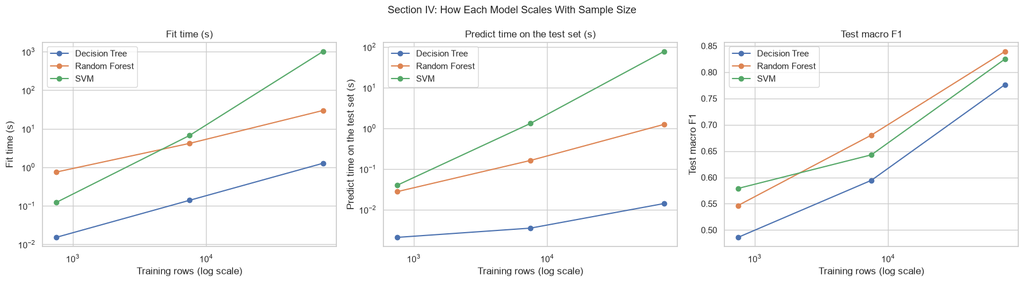

```python
# Plot fit time, predict time, and test macro F1 against the number of training rows

fig, axes = plt.subplots(1, 3, figsize=(18, 5))
scale_plots = [
    ("Fit Time (s)", "Fit time (s)", True),
    ("Predict Time (s)", "Predict time on the test set (s)", True),
    ("Macro F1", "Test macro F1", False),
]

for ax, (col, label, log_y) in zip(axes, scale_plots):
    for name in scale_models:
        rows = scale_results[scale_results["Model"] == name]
        ax.plot(rows["Train Rows"], rows[col], marker="o", label=name)
    ax.set_xscale("log")
    if log_y:
        ax.set_yscale("log")
    ax.set_xlabel("Training rows (log scale)")
    ax.set_ylabel(label)
    ax.set_title(label)
    ax.legend()

fig.suptitle("Section IV: How Each Model Scales With Sample Size", fontsize=13)
plt.tight_layout()
plt.show()
```

### IV C: Estimating Training Time on the Full Dataset

- For each model, a straight line is fit to log(fit time) vs. log(training rows), which is the same as assuming fit time = a * rows^k
- np.polyfit with degree 1 returns the slope (k) and the intercept (log a) of that line
- The line is then extended out to the full training set size to get an estimate
- This is only a rough estimate, because it is based on three points and assumes the growth rate stays the same at larger sizes
- For the SVM, the real growth often gets worse at large sizes (it also needs more memory), so its estimate is likely on the low side

```python
# Estimate how long each model would take to train on the full dataset

estimate_rows = []
for name in scale_models:
    rows = scale_results[scale_results["Model"] == name]
    slope, intercept = np.polyfit(np.log10(rows["Train Rows"]), np.log10(rows["Fit Time (s)"]), 1)
    estimated_seconds = 10 ** (intercept + slope * np.log10(full_train_rows))

    estimate_rows.append({
        "Model": name,
        "Growth Exponent (k)": slope,
        "Fit Time at 75k Rows (s)": rows["Fit Time (s)"].iloc[-1],
        "Estimated Full-Data Fit Time (min)": estimated_seconds / 60,
        "Test Macro F1 at 75k Rows": rows["Macro F1"].iloc[-1],
    })

scale_estimates = pd.DataFrame(estimate_rows).set_index("Model")
print(f"Estimates are for {full_train_rows:,} training rows (75% of the full dataset)")
scale_estimates.round(3)
```

```
Estimates are for 435,759 training rows (75% of the full dataset)
```

| Model | Growth Exponent (k) | Fit Time at 75k Rows (s) | Estimated Full-Data Fit Time (min) | Test Macro F1 at 75k Rows |
| --- | --- | --- | --- | --- |
| Decision Tree | 0.962 | 1.269 | 0.115 | 0.776 |
| Random Forest | 0.800 | 29.782 | 1.945 | 0.839 |
| SVM | 1.960 | 1011.036 | 447.912 | 0.825 |

### Section IV Results Discussion

The scalability experiment shows a large difference in how the three models respond to increasing sample size. Decision Tree remained extremely fast as the number of training observations increased. Its fit time increased from approximately 0.02 seconds on the 1,000-row sample to about 1.27 seconds on the 100,000-row sample. Random Forest required more time because 200 individual trees must be trained, but it also scaled reasonably well, increasing from approximately 0.75 seconds to about 29.8 seconds over the same range. In contrast, SVM became substantially more expensive as the sample size increased. Its training time increased from approximately 0.12 seconds on the smallest sample to more than 1,000 seconds, or about 17 minutes, when trained on 75,000 observations.

The estimated growth rates reinforce this difference. The Decision Tree had a growth exponent of approximately 0.96 and the Random Forest approximately 0.80, which suggests that their observed training times increased roughly linearly with the number of observations over the tested range. The SVM growth exponent was approximately 1.96, which is closer to quadratic growth. This means that increasing the dataset size has a much larger computational effect on SVM than on either of the tree-based models.

Prediction time shows a similar pattern. Decision Tree predictions remained nearly instantaneous, while Random Forest prediction time increased moderately as the sample size grew. SVM prediction was much slower because predictions with an RBF SVM depend on comparisons with support vectors from the training data. On the 100,000-row sample, prediction required approximately 78 seconds, compared with about 1.25 seconds for Random Forest and only a fraction of a second for Decision Tree.

As far as predictive performance, the larger samples improved predictive performance for all three models. At 75,000 training rows, the Decision Tree reached a macro F1 of approximately 0.776, Random Forest reached 0.839, and SVM reached 0.825. This is substantially higher than the results from the 20,000-row samples used in Section III, showing that all three models benefit from having more training data. Random Forest continued to provide the best balance between predictive performance and computational cost. SVM remained competitive in macro F1, but its additional training cost increased much faster than its performance advantage.

The scaling estimates were also used to determine which models can reasonably be trained on the full dataset. Using approximately 435,759 training observations, Decision Tree training is estimated to require only a few seconds, while Random Forest is estimated to require only a few minutes. Both models are therefore practical candidates for full-data training. In contrast, the estimated SVM training time is approximately 448 minutes, or about 7.5 hours, before prediction time is considered. Because of this computational cost, training the RBF SVM on the full dataset is not practical for this project.

Based on these results, the final Decision Tree and Random Forest models will be trained using the full training dataset. The final SVM will instead use a stratified sample of 100,000 training observations. This creates a limitation in the final comparison because SVM will not have access to as much training data as the two tree-based models. However, the smaller SVM training set reflects an important practical difference between the algorithms. Section V will therefore compare not only predictive performance, but also the computational cost and practicality of each approach.

### Section V: Final Model Training and Comparison

This section uses the best parameters found in Section III for each model. Decision Tree and Random Forest can be trained on the full dataset, since it was proven to be computationally feasible in section IV. Section IV determined that it is NOT computationally feasible to train SVM on the full dataset. Instead, the final SVM model will be trained on a stratified 100k observation sample.

The final parameters determined in the previous sections are as follows:

- Decision Tree: sklearn's default settings, because the basic tree beat the tuned tree in the Section III trials, trained on all training rows
- Random Forest: the Section II settings plus the max_features value chosen in Section IIIG, trained on all of the training rows
- SVM: the Section II settings, trained on the 100,000 row subset because of the time limits found in Section IV

Feature Importance:

- Impurity importance (built into the Random Forest): how much each feature reduced impurity, added up over every split in every tree. It is fast, but it is known to favor continuous features with many possible split points over the 0/1 columns
- Permutation importance: shuffle one feature at a time and measure how much the Random Forest's test macro F1 drops. If shuffling a feature barely changes the score, the model wasn't relying on it. This is slower, so it uses a 20,000 row stratified subset of the test set and 5 shuffles per feature
- Mutual information: a model-free score of how much knowing a feature reduces uncertainty about the cover type. It is calculated on the training subset, before any model is involved

#### V A: Final Train/Test Split

```python
# Section V setup: the final train/test split
# This section uses best_params and build_svm() from the III A setup cell, so that cell needs to be run first (it runs instantly)
# Sections II and III and the slow cells in Section IV do not need to be rerun

# Split the full dataset 75/25, stratified by cover type, using the same split function as every other section
X_train_full, X_test_full, y_train_full, y_test_full = split_features_target(df)
print(f"Final training rows: {len(X_train_full):,}   Final test rows: {len(X_test_full):,}")

# The SVM is too slow to train on all of the training rows (Section IV estimated many hours), so it is limited to a 100,000 row stratified subset of the training set
# The same subset is also used for the mutual information scores in V C, since those would be slow on all 435k rows
# These are the same rows that were used for the max_features tuning in III G, and they only come from the training set
subset_rows = 100_000
X_subset, _, y_subset, _ = train_test_split(
    X_train_full, y_train_full,
    train_size=subset_rows,
    stratify=y_train_full,
    random_state=RANDOM_STATE,
)
print(f"Training subset (SVM training and mutual information): {len(X_subset):,} rows")

# Final Random Forest settings: the Section II settings plus the max_features value chosen in III G (0.5 had the highest CV macro F1)
# The value is copied here so the III G tuning cell does not have to be rerun before this section
final_rf_params = {**best_params["Random Forest"], "max_features": 0.5}
print("Final Random Forest settings:", final_rf_params)
```

```
Final training rows: 435,759   Final test rows: 145,253
Training subset (SVM training and mutual information): 100,000 rows
Final Random Forest settings: {'max_depth': None, 'n_estimators': 200, 'class_weight': None, 'max_features': 0.5}
```

#### V B: Training the Final Models

```python
# Train the three final models and score them all on the same final test set

final_models = {
    "Decision Tree": DecisionTreeClassifier(random_state=RANDOM_STATE),
    "Random Forest": RandomForestClassifier(**final_rf_params, random_state=RANDOM_STATE),
    "SVM": build_svm(**best_params["SVM"]),
}

# Training data for each model
final_train_sets = {
    "Decision Tree": (X_train_full, y_train_full),
    "Random Forest": (X_train_full, y_train_full),
    "SVM": (X_subset, y_subset),
}

final_rows = []
final_preds = {}   # test set predictions for each model, used for the per-class results in V D

for name, model in final_models.items():
    X_tr, y_tr = final_train_sets[name]
    model_start = time.perf_counter()
    print(f"Training {name} on {len(X_tr):,} rows...")

    metrics, final_preds[name] = evaluate_model(model, X_tr, y_tr, X_test_full, y_test_full, return_predictions=True)
    final_rows.append({
        "Model": name,
        "Training Rows": len(X_tr),
        **metrics,
        "Overfit Gap": metrics["Train Accuracy"] - metrics["Test Accuracy"],
    })
    print(f"   done in {(time.perf_counter() - model_start) / 60:.1f} min "
          f"(test accuracy {metrics['Test Accuracy']:.4f}, macro F1 {metrics['Macro F1']:.4f})")

final_results = pd.DataFrame(final_rows).set_index("Model")
final_results.round(4)
```

```
Training Decision Tree on 435,759 rows...
   done in 0.1 min (test accuracy 0.9374, macro F1 0.9002)
Training Random Forest on 435,759 rows...
   done in 8.7 min (test accuracy 0.9672, macro F1 0.9426)
Training SVM on 100,000 rows...
   done in 46.2 min (test accuracy 0.8821, macro F1 0.8367)
```

| Model | Training Rows | Train Accuracy | Test Accuracy | Macro Precision | Macro Recall | Macro F1 | Fit Time (s) | Predict Time (s) | Overfit Gap |
| --- | --- | --- | --- | --- | --- | --- | --- | --- | --- |
| Decision Tree | 435759 | 1.0000 | 0.9374 | 0.9001 | 0.9004 | 0.9002 | 8.0281 | 0.0785 | 0.0626 |
| Random Forest | 435759 | 1.0000 | 0.9672 | 0.9537 | 0.9323 | 0.9426 | 493.1124 | 7.3017 | 0.0328 |
| SVM | 100000 | 0.9194 | 0.8821 | 0.8569 | 0.8191 | 0.8367 | 1835.6587 | 563.5798 | 0.0373 |

#### V C: Feature Importance

```
Permutation importance took 1.2 min
```

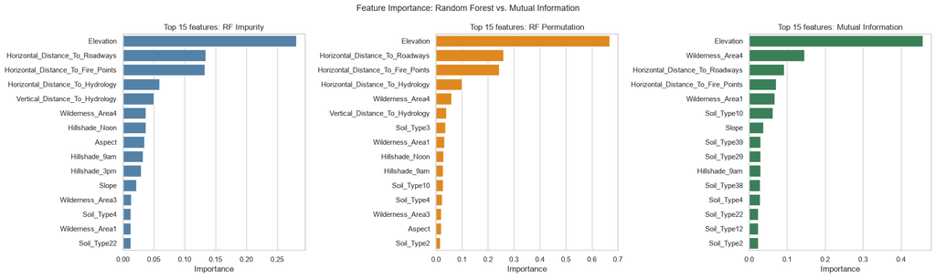

```
Spearman rank correlation between the three methods (all 54 features):
```

|  | RF Impurity | RF Permutation | Mutual Information |
| --- | --- | --- | --- |
| RF Impurity | 1.000 | 0.927 | 0.843 |
| RF Permutation | 0.927 | 1.000 | 0.831 |
| Mutual Information | 0.843 | 0.831 | 1.000 |

```
Top 15 features by permutation importance, with each method's rank:
```

|  | RF Impurity | RF Permutation | Mutual Information |
| --- | --- | --- | --- |
| Elevation | 1 | 1 | 1 |
| Horizontal_Distance_To_Roadways | 2 | 2 | 3 |
| Horizontal_Distance_To_Fire_Points | 3 | 3 | 4 |
| Horizontal_Distance_To_Hydrology | 4 | 4 | 19 |
| Wilderness_Area4 | 6 | 5 | 2 |
| Vertical_Distance_To_Hydrology | 5 | 6 | 23 |
| Soil_Type3 | 31 | 7 | 24 |
| Wilderness_Area1 | 14 | 8 | 5 |
| Hillshade_Noon | 7 | 9 | 21 |
| Hillshade_9am | 9 | 10 | 10 |
| Soil_Type10 | 19 | 11 | 6 |
| Soil_Type4 | 13 | 12 | 12 |
| Wilderness_Area3 | 12 | 13 | 31 |
| Aspect | 8 | 14 | 18 |
| Soil_Type2 | 16 | 15 | 15 |

```python
# Feature importance: three different ways of measuring which features matter most

final_rf = final_models["Random Forest"]

# Impurity importance comes for free with the fitted forest
impurity_imp = pd.Series(final_rf.feature_importances_, index=feature_cols)

# The forest is switched to use every CPU core for predicting, which speeds up the many predictions permutation importance needs
# This only affects prediction speed, not the model itself, and its fit time was already recorded above
final_rf.set_params(n_jobs=-1)
X_perm, _, y_perm, _ = train_test_split(
    X_test_full, y_test_full, train_size=20_000, stratify=y_test_full, random_state=RANDOM_STATE
)
perm_start = time.perf_counter()
perm_result = permutation_importance(
    final_rf, X_perm, y_perm, scoring="f1_macro", n_repeats=5, random_state=RANDOM_STATE
)
print(f"Permutation importance took {(time.perf_counter() - perm_start) / 60:.1f} min")
perm_imp = pd.Series(perm_result.importances_mean, index=feature_cols)

# Mutual information: the one-hot encoded wilderness and soil columns are marked as discrete so they are scored correctly
is_discrete = [col in wilderness_cols or col in soil_cols for col in feature_cols]
mi_imp = pd.Series(
    mutual_info_classif(X_subset, y_subset, discrete_features=is_discrete, random_state=RANDOM_STATE),
    index=feature_cols,
)

importance_df = pd.DataFrame({
    "RF Impurity": impurity_imp,
    "RF Permutation": perm_imp,
    "Mutual Information": mi_imp,
})

# Bar charts of the top 15 features for each method
fig, axes = plt.subplots(1, 3, figsize=(20, 6))
for ax, (method, color) in zip(axes, [("RF Impurity", "steelblue"), ("RF Permutation", "darkorange"), ("Mutual Information", "seagreen")]):
    top = importance_df[method].sort_values(ascending=False).head(15)
    sns.barplot(x=top.values, y=top.index, ax=ax, color=color)
    ax.set_title(f"Top 15 features: {method}")
    ax.set_xlabel("Importance")
    ax.set_ylabel("")
fig.suptitle("Feature Importance: Random Forest vs. Mutual Information", fontsize=13)
plt.tight_layout()
plt.show()

# Rank table: rank 1 is the most important feature for that method
# Showing ranks instead of raw scores makes the three methods comparable, since their scores are on very different scales
importance_ranks = importance_df.rank(ascending=False).astype(int)
top_by_perm = importance_ranks.sort_values("RF Permutation").head(15)

# Spearman correlation compares the full rankings of all 54 features
# A value near 1 means two methods put the features in nearly the same order
print("Spearman rank correlation between the three methods (all 54 features):")
display(importance_df.corr(method="spearman").round(3))
print("Top 15 features by permutation importance, with each method's rank:")
top_by_perm
```

#### V D: Per-Class Performance of the Final Models

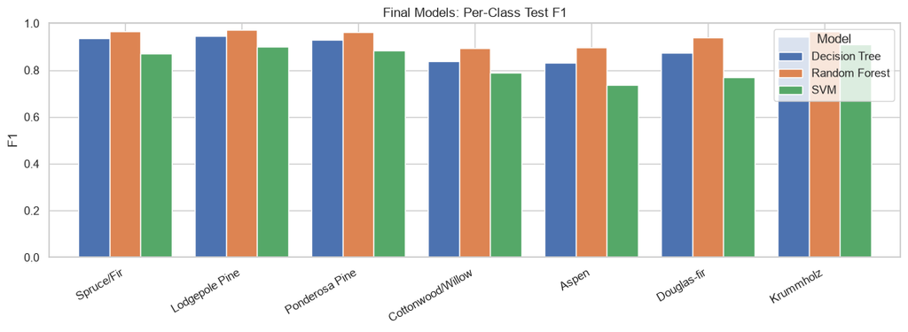

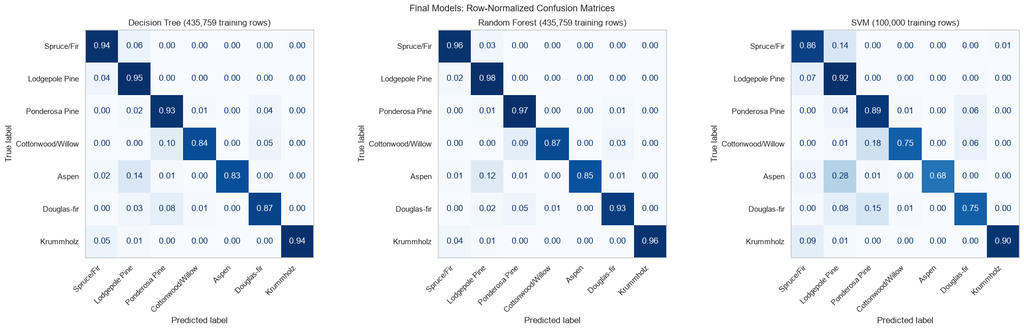

| Model Cover Type | Precision Decision Tree | Precision Random Forest | Precision SVM | Recall Decision Tree | Recall Random Forest | Recall SVM | F1 Decision Tree | F1 Random Forest | F1 SVM |
| --- | --- | --- | --- | --- | --- | --- | --- | --- | --- |
| Spruce/Fir | 0.936 | 0.971 | 0.890 | 0.937 | 0.963 | 0.856 | 0.936 | 0.967 | 0.872 |
| Lodgepole Pine | 0.948 | 0.967 | 0.882 | 0.946 | 0.978 | 0.916 | 0.947 | 0.972 | 0.899 |
| Ponderosa Pine | 0.928 | 0.957 | 0.879 | 0.931 | 0.970 | 0.887 | 0.930 | 0.964 | 0.883 |
| Cottonwood/Willow | 0.834 | 0.913 | 0.830 | 0.841 | 0.875 | 0.751 | 0.838 | 0.894 | 0.788 |
| Aspen | 0.833 | 0.944 | 0.805 | 0.832 | 0.852 | 0.677 | 0.832 | 0.896 | 0.736 |
| Douglas-fir | 0.874 | 0.947 | 0.790 | 0.874 | 0.930 | 0.749 | 0.874 | 0.939 | 0.769 |
| Krummholz | 0.948 | 0.975 | 0.922 | 0.941 | 0.958 | 0.898 | 0.944 | 0.967 | 0.909 |

```python
# Per-class results for the final models on the final test set
per_class_final_rows = []
for name in final_models:
    report = classification_report(
        y_test_full, final_preds[name],
        labels=class_labels, target_names=cover_type_order,
        output_dict=True, zero_division=0,
    )
    for cover in cover_type_order:
        per_class_final_rows.append({
            "Model": name,
            "Cover Type": cover,
            "Precision": report[cover]["precision"],
            "Recall": report[cover]["recall"],
            "F1": report[cover]["f1-score"],
        })
per_class_final = pd.DataFrame(per_class_final_rows)

# Grouped bar chart of per-class F1 for each final model
per_class_final_f1 = per_class_final.pivot(index="Cover Type", columns="Model", values="F1").reindex(cover_type_order)
fig, ax = plt.subplots(figsize=(12, 4.5))
per_class_final_f1[list(final_models)].plot.bar(ax=ax, width=0.8)
ax.set_title("Final Models: Per-Class Test F1")
ax.set_ylabel("F1")
ax.set_ylim(0, 1)
ax.set_xlabel("")
ax.tick_params(axis="x", rotation=30)
plt.setp(ax.get_xticklabels(), ha="right")
plt.tight_layout()
plt.show()

# Row-normalized confusion matrices, so each cell is the fraction of that true cover type predicted as each class
fig, axes = plt.subplots(1, 3, figsize=(21, 6.5))
for ax, name in zip(axes, final_models):
    cm = confusion_matrix(y_test_full, final_preds[name], labels=class_labels, normalize="true")
    ConfusionMatrixDisplay(cm, display_labels=cover_type_order).plot(
        ax=ax, cmap="Blues", values_format=".2f", colorbar=False
    )
    ax.set_title(f"{name} ({final_results.loc[name, 'Training Rows']:,} training rows)")
    ax.tick_params(axis="x", rotation=45)
    plt.setp(ax.get_xticklabels(), ha="right")
    ax.grid(False)
fig.suptitle("Final Models: Row-Normalized Confusion Matrices", fontsize=13)
plt.tight_layout()
plt.show()

per_class_final.pivot(index="Cover Type", columns="Model", values=["Precision", "Recall", "F1"]).reindex(cover_type_order).round(3)
```